# Script capítulo Coalescencia

Ruben Chaboy

# Tabla de contenidos

1. Carga de librerías
2. Preparación de los datos
3. Eliminación de controles y muestras no representativas
4. Eliminación de secuencias no bacterianas
5. Correción de NAs
6. Subsamplear
7. Guardado y carga
8. Análisis de diversidad y correlaciones
9. Creación de las variables de trabajo
10. Efecto de Riqueza y la diversidad filogenética sobre Carga y Peso
11. Análisis filogenético
    1. Top 10 familias
12. Análisis de la Composición Microbiana
    1. Composición Microbiana - Bray-Curtis
    2. Composición Microbiana - Cajas - Bray-Curtis
    3. Composición Microbiana - Unifrac
    4. Composición Microbiana - Cajas - Unifrac
13. Análisis de ASVs
    1. Gráficos Rainbow
    2. Gráficos Euler
14. Preparación de paneles
15. Red de resultados

## Carga de librerías y datos

Se cargan las librerías que se van a utilizar en el estudio. Se cargan los datos que provienen de seguir el procesado de secuencias siguiendo el flujo estándar del paquete DADA2. Estos datos contienen la tabla de abundancias de ASVs por muestra así como su asignación taxonómica.

```r
knitr::opts_knit$set(root.dir = getwd())
suppressMessages(suppressWarnings({
datos <- "dada2multithreads.RData"
suppressPackageStartupMessages({
library(dada2)
library(ggplot2)
library(here)
library(phyloseq)
library(microbiome)
library(dplyr)
library(writexl)
library(readxl)
library(openxlsx)
library(gridExtra)
library(patchwork)
library(Biostrings)
library(tidyr)
library(tibble)
library(vegan)
library(scales)
library(car)})
library(emmeans)
library(officer)
library(flextable)
library(patchwork)
library(broom)
library(pheatmap)
library(picante)
library(reshape2)
library(ppcor)
library(gtsummary)
library(stringr)
library(readr)
library(eulerr)
library(rlang)
library(gtools)
library(ragg)
library(magick)
library(igraph)
library(ggraph)
library(tidygraph)
theme_set(theme_bw())
load(here("data",datos)) }))

dir.create("test")
dir.create("graficos")
dir.create("graficos/individual")
dir.create("graficos/parejas")
out_graf <- "graficos"
out_graf_1 <- "graficos/individual"
out_graf_2 <- "graficos/parejas"

if (!dir.exists(out_graf_1)) dir.create(out_graf_1, recursive = TRUE)
if (!dir.exists(out_graf_2)) dir.create(out_graf_2, recursive = TRUE)
```

## Preparación de los datos

1. Se importan todos los datos del experimento (contenidos en un fichero Excel).
2. Creación del objeto phyloseq.

```r
samdf <- read_excel("metadata_Coales.xlsx")
samdf <- as.data.frame(samdf)


rownames(samdf) <- samdf$Nombre

ps <- phyloseq(otu_table(seqtab_nochim, taxa_are_rows = FALSE),
               sample_data(samdf),
               tax_table(tax))
```

### Eliminación de controles y muestras no representativas

Eliminación de aquellas muestras que corresponden a controles, controles de extracción de ADN (Cext) y controles negativos de PCR (Cneg). También se eliminan las muestras que contienen la comunidad B. Por último, se eliminan aquellas muestras que provienen de plantas muertas o pequeñas.

```r
ps_nocontrol <- subset_samples(
  ps,
  !(Tipo %in% c("Cext", "Cneg")) &
  !grepl("B", Componentes) &
  Observaciones %in% c("OK", "un poco seca", "seca")
)

ps_nocontrol <- subset_samples(
  ps,
  !(Tipo %in% c("Cext", "Cneg")) &
  !grepl("B", Componentes) &
   !Observaciones %in% c("muerta", "pequeña")
)
```

### Eliminación de secuencias no bacterianas

Eliminación de aquellas secuencias correspondientes a mitocondrias, cloroplastos y eucariotas. Esto es debido a que los primers elegidos pueden secuenciar el 16S de estos orgánulos.

```r
print("Inicial:")
```

```
## [1] "Inicial:"
```

```r
ps_nocontrol
```

```
## phyloseq-class experiment-level object
## otu_table()   OTU Table:         [ 6584 taxa and 71 samples ]
## sample_data() Sample Data:       [ 71 samples by 11 sample variables ]
## tax_table()   Taxonomy Table:    [ 6584 taxa by 6 taxonomic ranks ]
```

```r
inicial<-sum(otu_table(ps_nocontrol))
print ("Aqui vamos a quitar cloroplastos, mitocondrias y eucariotas")
```

```
## [1] "Aqui vamos a quitar cloroplastos, mitocondrias y eucariotas"
```

```r
ps_nocontrol_filtrado<- subset_taxa(ps_nocontrol, Class!="Chloroplast")
sin_cloroplastos<-sum(otu_table(ps_nocontrol_filtrado))
ps_nocontrol_filtrado <- subset_taxa(ps_nocontrol_filtrado, Family!="Mitochondria")
sin_mitocondrias<-sum(otu_table(ps_nocontrol_filtrado))
ps_nocontrol_filtrado <- subset_taxa(ps_nocontrol_filtrado, Kingdom!="Eukaryota")
sin_eucariotas<-sum(otu_table(ps_nocontrol_filtrado))
valores<-c(inicial,sin_cloroplastos,sin_mitocondrias,sin_eucariotas)
print("inicial,sin_cloroplastos,sin_mitocondrias,sin_eucariotas")
```

```
## [1] "inicial,sin_cloroplastos,sin_mitocondrias,sin_eucariotas"
```

```r
print(valores)
```

```
## [1] 4336737 4333705 4284779 4284675
```

```r
print(paste0("Total inicial= ",inicial))
```

```
## [1] "Total inicial= 4336737"
```

```r
print(paste0("  quitando cloroplastos= ",sin_cloroplastos))
```

```
## [1] "  quitando cloroplastos= 4333705"
```

```r
print(paste0("  quitando cloroplastos y mitocondrias= ",sin_mitocondrias))
```

```
## [1] "  quitando cloroplastos y mitocondrias= 4284779"
```

```r
print(paste0("  quitando cloroplastos, mitocondrias y eucariotas= ",sin_eucariotas))
```

```
## [1] "  quitando cloroplastos, mitocondrias y eucariotas= 4284675"
```

```r
print("Filtrado:")
```

```
## [1] "Filtrado:"
```

```r
ps_nocontrol_filtrado
```

```
## phyloseq-class experiment-level object
## otu_table()   OTU Table:         [ 4968 taxa and 71 samples ]
## sample_data() Sample Data:       [ 71 samples by 11 sample variables ]
## tax_table()   Taxonomy Table:    [ 4968 taxa by 6 taxonomic ranks ]
```

```r
suppressMessages(summarize_phyloseq(ps_nocontrol_filtrado))
```

```
## [[1]]
## [1] "1] Min. number of reads = 1880"
##
## [[2]]
## [1] "2] Max. number of reads = 159690"
##
## [[3]]
## [1] "3] Total number of reads = 4284675"
##
## [[4]]
## [1] "4] Average number of reads = 60347.5352112676"
##
## [[5]]
## [1] "5] Median number of reads = 53762"
##
## [[6]]
## [1] "7] Sparsity = 0.965327391077544"
##
## [[7]]
## [1] "6] Any OTU sum to 1 or less? YES"
##
## [[8]]
## [1] "8] Number of singletons = 2680"
##
## [[9]]
## [1] "9] Percent of OTUs that are singletons \n        (i.e. exactly one read detected across all samples)0.36231884057971"
##
## [[10]]
## [1] "10] Number of sample variables are: 11"
##
## [[11]]
##  [1] "Nombre"        "Replica"       "Numeromix"     "Componentes"
##  [5] "Tipo"          "MPN.ml"        "MPN"           "Peso_Seco"
##  [9] "Comments"      "Control"       "Observaciones"
```

### Correción de NAs

En el caso del peso Seco, a aquellas muestras que tienen valores NA (por no haber crecido lo suficiente la parte aérea) se les asocia un valor de 0 gramos.

1. Se reemplazan los valores de texto “NA” por valores NA (faltantes).
2. Se convierte la columna Peso a tipo numérico.
3. Se reemplazan los valores NA (faltantes) en la columna Peso con 0.

```r
sample_data(ps_nocontrol_filtrado)$MPN[sample_data(ps_nocontrol_filtrado)$MPN == "NA"] <- NA
sample_data(ps_nocontrol_filtrado)$MPN <- as.numeric(sample_data(ps_nocontrol_filtrado)$MPN)
sample_data(ps_nocontrol_filtrado)$MPN[is.na(sample_data(ps_nocontrol_filtrado)$MPN)] <- 220000
sample_data(ps_nocontrol_filtrado)$MPN[sample_data(ps_nocontrol_filtrado)$MPN < 220000] <- 110000

sample_data(ps_nocontrol_filtrado)$Peso_Seco[sample_data(ps_nocontrol_filtrado)$Peso_Seco == "NA"] <- NA
sample_data(ps_nocontrol_filtrado)$Peso_Seco <- as.numeric(sample_data(ps_nocontrol_filtrado)$Peso_Seco)
sample_data(ps_nocontrol_filtrado)$Peso_Seco[is.na(sample_data(ps_nocontrol_filtrado)$Peso_Seco)] <- 0
```

## Subsamplear

Se representa en una gráfica el número de secuencias por muestra para saber a cuánto subsamplear. Se utiliza una seed fija, 134.

```r
sort(sample_sums(ps_nocontrol_filtrado), decreasing = TRUE)
```

```
## Learning_NA_R3_74_S442 Learning_NA_R1_29_S303 Learning_NA_R1_66_S321
##                 159690                 137812                 117041
## Learning_NA_R1_68_S323 Learning_NA_R3_88_S451 Learning_NA_R1_24_S298
##                 104919                 104524                 103073
## Learning_NA_R1_64_S319 Learning_NA_R1_17_S292 Learning_NA_R1_81_S336
##                  98922                  98751                  98325
## Learning_NA_R1_56_S317 Learning_NA_R2_19_S363 Learning_NA_R1_11_S289
##                  92525                  88630                  88088
##  Learning_NA_R1_6_S287 Learning_NA_R1_27_S301 Learning_NA_R1_72_S327
##                  85587                  83725                  82679
##  Learning_NA_R3_5_S571 Learning_NA_R3_25_S427 Learning_NA_R2_88_S418
##                  80321                  77397                  73028
## Learning_NA_R2_79_S410 Learning_NA_R2_22_S364 Learning_NA_R3_85_S549
##                  72486                  71374                  70924
## Learning_NA_R3_41_S567 Learning_NA_R2_35_S375 Learning_NA_R3_36_S540
##                  68402                  67989                  66584
## Learning_NA_R3_77_S444 Learning_NA_R1_67_S322 Learning_NA_R1_40_S309
##                  65932                  65776                  65458
## Learning_NA_R1_84_S339 Learning_NA_R3_43_S573 Learning_NA_R2_39_S378
##                  62379                  60065                  57846
## Learning_NA_R2_43_S379 Learning_NA_R3_30_S512 Learning_NA_R2_65_S396
##                  57360                  57050                  56248
## Learning_NA_R1_49_S313 Learning_NA_R3_11_S425 Learning_NA_R1_12_S290
##                  55200                  55073                  53762
## Learning_NA_R2_86_S417 Learning_NA_R2_20_S496 Learning_NA_R1_39_S531
##                  53446                  51427                  50983
## Learning_NA_R3_53_S541 Learning_NA_R1_60_S518 Learning_NA_R3_92_S455
##                  50305                  49715                  48984
## Learning_NA_R1_54_S570 Learning_NA_R3_57_S568 Learning_NA_R3_45_S432
##                  48868                  48426                  47148
## Learning_NA_R1_59_S510 Learning_NA_R3_23_S572 Learning_NA_R1_45_S558
##                  46407                  44970                  44787
##  Learning_NA_R3_3_S559 Learning_NA_R3_19_S546 Learning_NA_R3_20_S553
##                  44438                  43367                  42505
## Learning_NA_R3_44_S500 Learning_NA_R3_31_S520 Learning_NA_R1_58_S503
##                  41702                  40832                  40560
##  Learning_NA_R3_2_S552 Learning_NA_R1_42_S544 Learning_NA_R1_10_S550
##                  40270                  40108                  38323
## Learning_NA_R1_13_S557 Learning_NA_R2_55_S484 Learning_NA_R1_55_S497
##                  37272                  37239                  36910
## Learning_NA_R3_18_S539 Learning_NA_R2_73_S404 Learning_NA_R3_34_S527
##                  35690                  33937                  33892
## Learning_NA_R3_80_S447 Learning_NA_R3_70_S522 Learning_NA_R3_15_S526
##                  32735                  31657                  30043
## Learning_NA_R2_87_S487 Learning_NA_R3_81_S529 Learning_NA_R2_24_S490
##                  29449                  27886                  26851
##  Learning_NA_R1_5_S530 Learning_NA_R2_80_S411
##                  26718                   1880
```

```r
suppressMessages(suppressWarnings({
  set.seed(134)
  ps_nocontrol_filtrado_rare <- rarefy_even_depth(ps_nocontrol_filtrado, sample.size = 23394, trimOTUs = TRUE)
}))

png("graficos/profundidad_secuenciacion.png", width = 800, height = 600)

plot(
  sort(sample_sums(ps_nocontrol_filtrado)),
  ylab = "Profundidad de secuenciación",
  xlab = "Muestras ordenadas por profundidad",
  main = "Profundidad de secuenciación por muestra",
  cex.lab = 1.6,
  cex.axis = 1.4,
  cex.main = 1.8
)
abline(h = 23394, col = "red", lwd = 2)

dev.off()
```

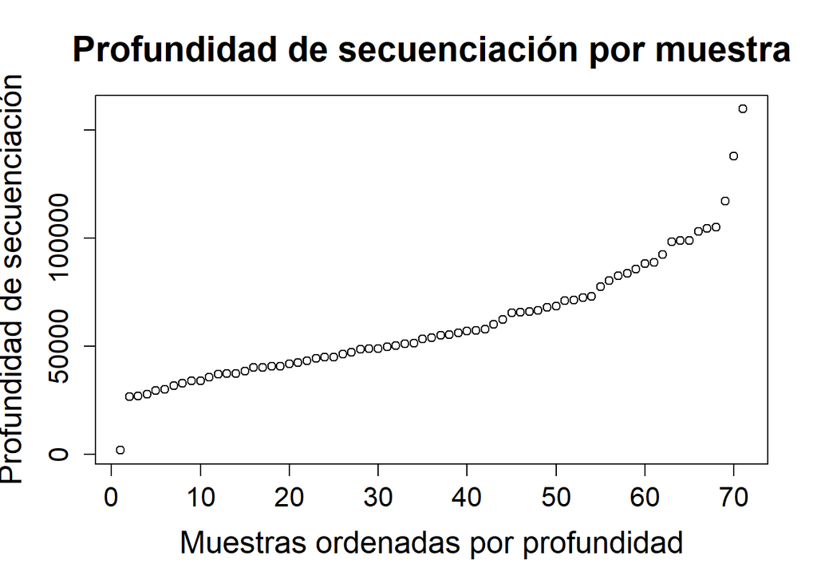

```r
plot(
  sort(sample_sums(ps_nocontrol_filtrado)),
  ylab = "Profundidad de secuenciación",
  xlab = "Muestras ordenadas por profundidad",
  main = "Profundidad de secuenciación por muestra",
  cex.lab = 1.6,
  cex.axis = 1.4,
  cex.main = 1.8
)
```

## Guardado y carga

Guardado del objeto phylosec.

```r
saveRDS(ps_nocontrol_filtrado_rare, "ps_nocontrol_filtrado_rare.rds")
```

En otro script, partiendo del objeto phyloseq anterior, se “mapean” sus secuencias contra una base de datos de referencia con árbol y taxonomía asociados (ej. greengenes2). De esta forma se incluye el árbol filogenético en el objeto y se pueden realizar análisis mediante medidas filogenéticas (ej.: Faith, unifrac,…).

```r
nuevosdatos <- "phyloseq_objects_with_tree.Rdata"

load(here("data",nuevosdatos ))
```

# **Análisis de diversidad y correlaciones**

## Creación de las variables de trabajo

```r
datos_est <- as(sample_data(ps_nocontrol_filtrado_rare), "data.frame")
datos_est$log_MPN <- log10(datos_est$MPN)

Riqueza <- estimate_richness(ps_nocontrol_filtrado_rare, measures = "Observed")
Homogeneidad <- estimate_richness(ps_nocontrol_filtrado_rare, measures = "Shannon")

Faith_D <- pd(as(otu_table(new_ps), "matrix"), phy_tree(new_ps))
datos_est$Riqueza <- Riqueza[rownames(datos_est), "Observed"]
datos_est$Homogeneidad <- Homogeneidad[rownames(datos_est), "Shannon"]
datos_est$Faith_D <- Faith_D[rownames(datos_est), "PD"]

# Aseguramos los tipos de variable

datos_est$Componentes   <- factor(datos_est$Componentes)
datos_est$Tipo   <- factor(datos_est$Tipo)


#Preparación de datos para análisis posteriores
abundancia_rel <- transform_sample_counts(ps_nocontrol_filtrado_rare, function(x) x / sum(x))
abundancia_rel_df <- as.data.frame(otu_table(abundancia_rel))

abund_t <- t(abundancia_rel_df)
abund_t <- abund_t %>%
  as.data.frame() %>%
  tibble::rownames_to_column("clade_name")

abund_t <- as_tibble(abund_t)

# crear IDs nuevos "T_Coal_001", "T_Coal_002", ...
n <- nrow(abund_t)
width <- max(3, nchar(as.character(n)))
new_ids <- sprintf(paste0("T_Coal_%0", width, "d"), seq_len(n))

# 2) conservar la secuencia original y sustituir clade_name por el ID
abund_t <- abund_t %>%
  mutate(
    original_seq = as.character(clade_name),
    clade_name = new_ids
  )
```

```r
table(sample_data(ps_nocontrol_filtrado_rare)$Componentes)
```

```
##
##  A AC AD AE AF AG AH  C CD CE CF CG CH  D DE DF DG DH  E EF EG EH  F FG FH  G
##  2  2  3  3  2  3  2  2  2  2  2  2  3  3  2  3  3  3  3  2  2  3  3  2  3  3
## GH  H
##  2  3
```

### Efecto de Riqueza y la diversidad filogenética sobre Carga y Peso

Se calcula el efecto de Riqueza y la diversidad filogenética sobre Carga y Peso. Primero se analiza si existe una correlación entre ambas variables y, en caso de detectarse, se calcula la fracción de la diversidad filogenética que es independiente de Riqueza. A continuación, se calculan los efectos de Riqueza y la fracción de la diversidad filogenética independiente de Riqueza sobre Carga y Peso.

```r
options(contrasts = c("contr.sum", "contr.poly"))

# 1) Exploración inicial ---------------------------------------------------
# Scatterplot de Riqueza vs Faith_D con smoothing y recta para ver linealidad

png("graficos/riqueza_vs_faith.png", width = 800, height = 600)

par(mar = c(5, 6.5, 4, 2) + 0.1,
    mgp = c(2.5, 0.8, 0))

plot(datos_est$Riqueza, datos_est$Faith_D,
     xlab = "Riqueza", ylab = "Diversidad",
     main = "Riqueza frente a Diversidad",
     cex.lab = 1.8,
     cex.axis = 1.6,
     cex.main = 2.2,
     cex = 1.2,
     pch = 20, col = "grey30")

lines(lowess(datos_est$Riqueza, datos_est$Faith_D), col = "blue")
abline(lm(Faith_D ~ Riqueza, data = datos_est), col = "red", lwd = 2)

dev.off()
```

```r
# Correlación (numérico)
r_rich_pd <- cor(datos_est$Riqueza, datos_est$Faith_D)
cat("Correlación Riqueza - Faith_D:", round(r_rich_pd, 3), "\n")
```

```
## Correlación Riqueza - Faith_D: 0.851
```

```r
# Interpretación: r alto (ej. 0.85) indica solapamiento importante.

# 2) Residualizar Faith_D respecto a Riqueza (parte independiente de PD) ----
# Como la relación resultó lineal (confirmado), usamos resid(lm)
m_pd_vs_r <- lm(Faith_D ~ Riqueza, data = datos_est)
datos_est$PD_resid <- resid(m_pd_vs_r)   # PD residualizado (parte no explicada por Riqueza)

# Modelo final con la PD residualizada
m_final_Peso <- lm(Peso_Seco ~ Riqueza + PD_resid, data = datos_est)
cat("Resumen modelo final (Peso_Seco ~ Riqueza + PD_resid):\n");
```

```
## Resumen modelo final (Peso_Seco ~ Riqueza + PD_resid):
```

```r
lmtest::bptest(m_final_Peso)
```

```
##
##  studentized Breusch-Pagan test
##
## data:  m_final_Peso
## BP = 0.76214, df = 2, p-value = 0.6831
```

```r
print(summary(m_final_Peso))
```

```
##
## Call:
## lm(formula = Peso_Seco ~ Riqueza + PD_resid, data = datos_est)
##
## Residuals:
##       Min        1Q    Median        3Q       Max
## -0.024555 -0.009672  0.001641  0.010113  0.021570
##
## Coefficients:
##               Estimate Std. Error t value Pr(>|t|)
## (Intercept)  1.840e-02  5.137e-03   3.582 0.000642 ***
## Riqueza      6.992e-05  2.978e-05   2.348 0.021852 *
## PD_resid    -8.978e-07  5.178e-06  -0.173 0.862870
## ---
## Signif. codes:  0 '***' 0.001 '**' 0.01 '*' 0.05 '.' 0.1 ' ' 1
##
## Residual standard error: 0.01256 on 67 degrees of freedom
## Multiple R-squared:  0.07639,    Adjusted R-squared:  0.04882
## F-statistic: 2.771 on 2 and 67 DF,  p-value: 0.06979
```

```r
print(Anova(m_final_Peso, type = "II"))
```

```
## Anova Table (Type II tests)
##
## Response: Peso_Seco
##              Sum Sq Df F value  Pr(>F)
## Riqueza   0.0008696  1  5.5116 0.02185 *
## PD_resid  0.0000047  1  0.0301 0.86287
## Residuals 0.0105705 67
## ---
## Signif. codes:  0 '***' 0.001 '**' 0.01 '*' 0.05 '.' 0.1 ' ' 1
```

```r
#PARA MPN

# 3) Residualizar Faith_D respecto a Riqueza (parte independiente de PD) ----
# Modelo final con la PD residualizada: la interpretación es clara.
m_final_MPN <- lm(log_MPN ~ Riqueza + PD_resid, data = datos_est)
cat("Resumen modelo final (MPN ~ Riqueza + PD_resid):\n");
```

```
## Resumen modelo final (MPN ~ Riqueza + PD_resid):
```

```r
lmtest::bptest(m_final_MPN)
```

```
##
##  studentized Breusch-Pagan test
##
## data:  m_final_MPN
## BP = 1.0198, df = 2, p-value = 0.6006
```

```r
print(summary(m_final_MPN))
```

```
##
## Call:
## lm(formula = log_MPN ~ Riqueza + PD_resid, data = datos_est)
##
## Residuals:
##      Min       1Q   Median       3Q      Max
## -1.66162 -0.34810 -0.02491  0.40645  1.16172
##
## Coefficients:
##              Estimate Std. Error t value Pr(>|t|)
## (Intercept) 8.9705865  0.2459174  36.478   <2e-16 ***
## Riqueza     0.0008191  0.0014258   0.574    0.568
## PD_resid    0.0002690  0.0002479   1.085    0.282
## ---
## Signif. codes:  0 '***' 0.001 '**' 0.01 '*' 0.05 '.' 0.1 ' ' 1
##
## Residual standard error: 0.6013 on 67 degrees of freedom
## Multiple R-squared:  0.022,  Adjusted R-squared:  -0.007195
## F-statistic: 0.7535 on 2 and 67 DF,  p-value: 0.4746
```

```r
print(Anova(m_final_MPN, type = "II"))
```

```
## Anova Table (Type II tests)
##
## Response: log_MPN
##            Sum Sq Df F value Pr(>F)
## Riqueza    0.1193  1  0.3300 0.5676
## PD_resid   0.4256  1  1.1771 0.2818
## Residuals 24.2276 67
```

# **Análisis filogenético**

## Top 10 familias

Se calculan las 10 familias más abundantes de las muestras de cada componente.

```r
# Al haber rarificado se realiza de la siguiente manera

ps_familia <- tax_glom(ps_nocontrol_filtrado_rare, taxrank = "Family")
ps_familia_rel <- transform_sample_counts(ps_familia, function(x) x / sum(x))


#Añadir "Otros" al gráfico
df <- phyloseq::psmelt(ps_familia_rel) |>
  mutate(
    Family = as.character(Family),
    Family = ifelse(is.na(Family) | Family == "", "Unassigned", Family),
    Family_plot = forcats::fct_lump_n(Family, n = 10, w = Abundance, other_level = "Otros")
  )


# Sumar por muestra (Top 10)

per_sample<- df |>
  group_by(Sample, Componentes, Family_plot) |>
  summarise(Abund_rel = sum(Abundance), .groups = "drop")

# Promedio por grupo

familia_plot <- per_sample |>
  group_by(Componentes, Family_plot) |>
  summarise(NormalizedAbundance = mean(Abund_rel), .groups = "drop")


# Reordenamos Family_plot por abundancia media para que la leyenda aparezca ordenada
familia_plot <- familia_plot |>
  mutate(
    Family_plot = forcats::fct_reorder(Family_plot, NormalizedAbundance, .fun = mean, .desc = TRUE),
    Family_plot = forcats::fct_relevel(Family_plot, "Otros", after = Inf)
  )


Top10_otros <- ggplot(familia_plot, aes(x = Componentes, y = NormalizedAbundance, fill = Family_plot)) +
  geom_bar(stat = "identity", position = "stack", width = 0.7) +
  scale_fill_brewer(palette = "Set3") +
  labs(
    title = "Top10 familias",
    x = "Componentes",
    y = "Abundancia relativa",
    fill = "Familia"
  ) +
  theme_bw() +
    guides(fill = guide_legend(nrow = 2)) +
  theme(
    axis.text.x = element_text(size = 12, angle = 45, hjust = 1),
    axis.text.y = element_text(size = 12, ),
    axis.title.x = element_text(size = 14),
    axis.title.y = element_text(size = 14),
    plot.title = element_text(hjust = 0.5, face = "bold", size = 16),
    legend.title = element_text(size = 14, face = "bold"),
    legend.text = element_text(size = 12),
    legend.position = "bottom",
    strip.text = element_text(size = 12, face = "bold")
   )


ggsave("graficos/Top10_Familias_otros.png",
       plot = Top10_otros, width = 14, height = 6, dpi = 300)
```

## **Análisis de la Composición Microbiana**

## Composición Microbiana - Bray-Curtis

En este apartado primero se crea un bucle para generar todos los objetos phyloseq para todas las combinaciones de parejas. Cada objeto contendrá las muestras de los componentes individuales y las de la propia pareja. Con el segundo bucle se representa, para cada uno de los objetos anteriores, la composición microbiana, mediante análisis NMDS utilizando distancias Bray-Curtis.

```r
Suelos <- c("A", "C", "D", "E", "F", "G", "H")
pares <- combn(Suelos, 2, simplify = FALSE)

# Crear y guardar plots individuales
all_plots <- list()

for (par in pares) {
  comp1 <- par[1]
  comp2 <- par[2]
  Pareja <- paste0(comp1, comp2)
  obj_pareja <- paste0("ps_nocontrol_filtrado_rare", Pareja)

  ps_filtrado_pareja <- subset_samples(
    ps_nocontrol_filtrado_rare,
    Componentes %in% c(comp1, comp2, Pareja)
  )
  assign(obj_pareja, ps_filtrado_pareja)
}

for (par in pares) {
  comp1 <- par[1]
  comp2 <- par[2]

  pareja <- paste0(comp1, comp2)
  ps_filtrado_pareja <- get(paste0("ps_nocontrol_filtrado_rare", pareja))
  ps_prop_pareja <- transform_sample_counts(ps_filtrado_pareja, function(otu) otu / sum(otu))

set.seed(123)
  ord_nmds_bray_pareja <- ordinate(ps_prop_pareja, method = "NMDS", distance = "bray")
  assign(paste0("ps_prop_", pareja), ps_prop_pareja)
  assign(paste0("ord_nmds_bray_", pareja), ord_nmds_bray_pareja)
}
```

```
## *** Best solution repeated 2 times
```

```
## *** Best solution repeated 17 times
```

```
## *** Best solution was not repeated -- monoMDS stopping criteria:
##      5: no. of iterations >= maxit
##     15: stress < smin
```

```
## *** Best solution repeated 1 times
```

```
## *** Best solution repeated 10 times
## *** Best solution repeated 15 times
```

```
## *** Best solution repeated 3 times
```

```
## *** Best solution was not repeated -- monoMDS stopping criteria:
##      3: no. of iterations >= maxit
##     12: stress < smin
##      5: scale factor of the gradient < sfgrmin
```

```
## *** Best solution repeated 3 times
```

```
## *** Best solution was not repeated -- monoMDS stopping criteria:
##     11: no. of iterations >= maxit
##      6: stress < smin
##      1: stress ratio > sratmax
##      2: scale factor of the gradient < sfgrmin
```

```
## *** Best solution was not repeated -- monoMDS stopping criteria:
##      8: no. of iterations >= maxit
##      6: stress < smin
##      1: stress ratio > sratmax
##      5: scale factor of the gradient < sfgrmin
```

```
## *** Best solution was not repeated -- monoMDS stopping criteria:
##      3: no. of iterations >= maxit
##     12: stress < smin
##      4: stress ratio > sratmax
##      1: scale factor of the gradient < sfgrmin
```

```
## *** Best solution repeated 10 times
## *** Best solution repeated 11 times
```

```
## *** Best solution repeated 2 times
## *** Best solution repeated 4 times
```

```
## *** Best solution was not repeated -- monoMDS stopping criteria:
##      9: no. of iterations >= maxit
##      7: stress < smin
##      3: stress ratio > sratmax
##      1: scale factor of the gradient < sfgrmin
```

```
## *** Best solution repeated 1 times
## *** Best solution repeated 2 times
## *** Best solution repeated 1 times
## *** Best solution repeated 12 times
```

```r
for (par in pares) {
  comp1 <- par[1]
  comp2 <- par[2]
  pareja <- paste0(comp1, comp2)

  ps_prop_pareja <- get(paste0("ps_prop_", pareja))
  ord_nmds_bray_pareja <- get(paste0("ord_nmds_bray_", pareja))


p_pareja <- plot_ordination(
  ps_prop_pareja, ord_nmds_bray_pareja,
  shape = "Tipo", color = "Componentes",
  title = paste("NMDS Bray-Curtis")
)
    p_pareja$layers <- p_pareja$layers[-1]


p_pareja <- p_pareja +
  geom_point(
    aes(fill = Componentes, shape = Tipo),
    size = 4,
    stroke = 0.8,
    color = "black",
    position = position_jitter(width = 0.09, height = 0.09)
  ) +
  scale_shape_manual(values = c(Individual = 22, Pareja = 21)) +
  scale_fill_brewer(palette = "Set1") +   # o Set2 / Dark2
  guides(
    fill  = guide_legend(override.aes = list(shape = 21, color = "black")),
    shape = guide_legend(override.aes = list(fill = "white", color = "black"))
  ) +
  theme_minimal() +
    theme(
      plot.title = element_text(hjust = 0.5, face = "bold"),
      plot.background = element_rect(fill = "white", color = NA),
      panel.background = element_rect(fill = "white", color = NA),
      axis.text.x = element_text(angle = 0, hjust = 1, size = 10),
      axis.text.y = element_text(size = 10),
      legend.title = element_text(margin = margin(b = 10)))

  # Guardar plot individual
  ggsave(filename = paste0("graficos/parejas/Bray-Curtis/NMDS_", pareja, ".png"),
         plot = p_pareja, width = 7, height = 5)

  # Guardar en lista para paneles
  all_plots[[pareja]] <- p_pareja
}
```

## Composición Microbiana - Cajas - Bray-Curtis

Para cada combinación de comunidades, se calcula las distancias de Bray-Curtis para evaluar:

- la variabilidad dentro de cada comunidad (intra-grupo).
- la diferencia entre cada comunidad y su mezcla (inter-grupo).

Por último, se representan con diagramas de cajas.

```r
Suelos <- c("A", "C", "D", "E", "F", "G", "H")
pares <- combn(Suelos, 2, simplify = FALSE)

out_dir_plots <- "graficos/parejas/cajas_BrayCurtis"
out_dir_tables <- "parejas/bray"
dir.create(out_dir_plots, recursive = TRUE, showWarnings = FALSE)
dir.create(out_dir_tables, recursive = TRUE, showWarnings = FALSE)

# Cambiar los labels si fuera necesario
GROUP_COL <- "Componentes"
MIX_COL <- "Tipo"
INDIV_LABEL <- "Individual"
PAIR_LABEL <- "Pareja"
TRANSFORM_TO_PROPORTIONS <- TRUE

# -----------------------------
# Preparación de funciones
# -----------------------------
.dist_values <- function(dist_mat, ids1, ids2 = ids1) {
  ids1 <- intersect(ids1, rownames(dist_mat))
  ids2 <- intersect(ids2, colnames(dist_mat))
  if (length(ids1) == 0 || length(ids2) == 0) return(numeric(0))

  if (identical(ids1, ids2)) {
    sub <- dist_mat[ids1, ids1, drop = FALSE]
    return(sub[upper.tri(sub, diag = FALSE)])
  } else {
    return(as.numeric(dist_mat[ids1, ids2, drop = FALSE]))
  }
}

# -----------------------------
# Calcular distancias Bray-Curtis por bloques para una pareja XY (función por defecto)
# -----------------------------
calcular_distancias_entre_grupos <- function(ps_objeto, comp1, comp2, pareja,
                                             group_col = "Componentes",
                                             mix_col = "Tipo",
                                             indiv_label = "Individual",
                                             pair_label = "Pareja",
                                             transform_to_proportions = TRUE) {
  ps_use <- ps_objeto

  if (transform_to_proportions) {
    ps_use <- transform_sample_counts(ps_use, function(x) if (sum(x) > 0) x / sum(x) else x)
  }

  # distancia Bray-Curtis
  dist_df <- as.matrix(phyloseq::distance(ps_use, method = "bray"))

  md <- data.frame(sample_data(ps_use), stringsAsFactors = FALSE) %>%
    tibble::rownames_to_column("SampleID")

  if (!group_col %in% colnames(md)) {
    stop("No existe columna '", group_col, "' en sample_data(). Columnas: ",
         paste(colnames(md), collapse = ", "))
  }
  if (!mix_col %in% colnames(md)) {
    stop("No existe columna '", mix_col, "' en sample_data(). Columnas: ",
         paste(colnames(md), collapse = ", "))
  }

  md[[group_col]] <- as.character(md[[group_col]])
  md[[mix_col]] <- as.character(md[[mix_col]])

  # IDs de muestras por bloque
  m1 <- md %>%
    filter(.data[[group_col]] == comp1, .data[[mix_col]] == indiv_label) %>%
    pull(SampleID)

  m2 <- md %>%
    filter(.data[[group_col]] == comp2, .data[[mix_col]] == indiv_label) %>%
    pull(SampleID)

  mp <- md %>%
    filter(.data[[group_col]] == pareja, .data[[mix_col]] == pair_label) %>%
    pull(SampleID)

  out <- list()

  # intragrupo comp1
  v <- .dist_values(dist_df, m1)
  if (length(v) > 0) out[[length(out) + 1]] <- tibble(
    Pareja = pareja,
    Grupo = paste0(comp1, " intra"),
    Distancia = v
  )

  # comp1 vs pareja
  v <- .dist_values(dist_df, m1, mp)
  if (length(v) > 0) out[[length(out) + 1]] <- tibble(
    Pareja = pareja,
    Grupo = paste0(comp1, " vs ", pareja),
    Distancia = v
  )

  # intragrupo comp2
  v <- .dist_values(dist_df, m2)
  if (length(v) > 0) out[[length(out) + 1]] <- tibble(
    Pareja = pareja,
    Grupo = paste0(comp2, " intra"),
    Distancia = v
  )

  # comp2 vs pareja
  v <- .dist_values(dist_df, m2, mp)
  if (length(v) > 0) out[[length(out) + 1]] <- tibble(
    Pareja = pareja,
    Grupo = paste0(comp2, " vs ", pareja),
    Distancia = v
  )

  if (length(out) == 0) return(NULL)
  bind_rows(out)
}

# ============================================================
# Paso final: para cada pareja, calcula distancias y guarda la gráfica
# ============================================================
all_dist <- list()

for (par in pares) {
  comp1 <- par[1]
  comp2 <- par[2]
  pareja <- paste0(comp1, comp2)

  message("Procesando pareja: ", pareja)

  obj_name <- paste0("ps_nocontrol_filtrado_rare", pareja)
  if (!exists(obj_name, inherits = TRUE)) {
    message("  ✗ No existe objeto: ", obj_name, " (saltando)")
    next
  }

  ps_filtrado_pareja <- get(obj_name, inherits = TRUE)

  ps_filtrado_pareja <- prune_taxa(taxa_sums(ps_filtrado_pareja) > 0, ps_filtrado_pareja)
  ps_filtrado_pareja <- prune_samples(sample_sums(ps_filtrado_pareja) > 0, ps_filtrado_pareja)

  #Se seleccionan los datos para usar, sino usarán los que están por defecto

  dist_data <- calcular_distancias_entre_grupos(
    ps_objeto = ps_filtrado_pareja,
    comp1 = comp1,
    comp2 = comp2,
    pareja = pareja,
    group_col = GROUP_COL,
    mix_col = MIX_COL,
    indiv_label = INDIV_LABEL,
    pair_label = PAIR_LABEL,
    transform_to_proportions = TRANSFORM_TO_PROPORTIONS
  )

  if (is.null(dist_data) || nrow(dist_data) == 0) {
    message("  ✗ No hay suficientes datos para ", pareja)
    next
  }

  all_dist[[pareja]] <- dist_data

  # orden fijo de cajas
  orden_grupos <- c(
    paste0(comp1, " intra"),
    paste0(comp1, " vs ", pareja),
    paste0(comp2, " intra"),
    paste0(comp2, " vs ", pareja)
  )
  orden_grupos <- orden_grupos[orden_grupos %in% unique(dist_data$Grupo)]
dist_data$Grupo <- factor(dist_data$Grupo, levels = orden_grupos)

colores_cajas <- c()
for (grupo in orden_grupos) {
  if (grepl("intra", grupo)) {
    if (grepl(paste0("^", comp1), grupo)) {
      colores_cajas <- c(colores_cajas, "#E74C3C")  # Rojo (comp1 intra)
    } else {
      colores_cajas <- c(colores_cajas, "#3498DB")  # Azul (comp2 intra)
    }
  } else {
    if (grepl(paste0("^", comp1, " vs"), grupo)) {
      colores_cajas <- c(colores_cajas, "#F39C12")  # Naranja (comp1 vs pareja)
    } else {
      colores_cajas <- c(colores_cajas, "#9B59B6")  # Morado (comp2 vs pareja)
    }
  }
}
names(colores_cajas) <- orden_grupos

  p_box <- ggplot(dist_data, aes(x = Grupo, y = Distancia, fill = Grupo)) +
    geom_boxplot(alpha = 0.7, outlier.shape = NA) +
    geom_jitter(width = 0.2, alpha = 0.5, size = 2, aes(color = Grupo)) +
    scale_fill_manual(values = colores_cajas, name = "Comparación") +  #añadido nuevo
     scale_color_manual(values = colores_cajas, guide = "none") + #añadido
    labs(
      title = paste("Análisis intra e inter Grupo (Distancias Bray-Curtis)"),
      x = "Comparación de componentes",
      y = "Distancia Bray–Curtis"
    ) +
    theme_minimal() +
 theme(
  plot.margin = margin(2, 2, 2, 2, unit = "pt"),
  axis.title.y = element_text(size = 14),
  axis.title.x = element_text(size = 14),
  plot.title = element_text(size = 20, face = "bold", hjust = 0.5),
  axis.text.x = element_text(angle = 45, hjust = 1, size = 14),
  axis.text.y = element_text(size = 14),
  legend.position = "none"
)

  ggsave(
    filename = file.path(out_dir_plots, paste0("Boxplot_", pareja, ".png")),
    plot = p_box, width = 10, height = 6, dpi = 300
  )

  message("  ✓ Guardado: ", file.path(out_dir_plots, paste0("Boxplot_", pareja, ".png")))
}
```

```
## Procesando pareja: AC
```

```
##   ✓ Guardado: graficos/parejas/cajas_BrayCurtis/Boxplot_AC.png
```

```
## Procesando pareja: AD
```

```
##   ✓ Guardado: graficos/parejas/cajas_BrayCurtis/Boxplot_AD.png
```

```
## Procesando pareja: AE
```

```
##   ✓ Guardado: graficos/parejas/cajas_BrayCurtis/Boxplot_AE.png
```

```
## Procesando pareja: AF
```

```
##   ✓ Guardado: graficos/parejas/cajas_BrayCurtis/Boxplot_AF.png
```

```
## Procesando pareja: AG
```

```
##   ✓ Guardado: graficos/parejas/cajas_BrayCurtis/Boxplot_AG.png
```

```
## Procesando pareja: AH
```

```
##   ✓ Guardado: graficos/parejas/cajas_BrayCurtis/Boxplot_AH.png
```

```
## Procesando pareja: CD
```

```
##   ✓ Guardado: graficos/parejas/cajas_BrayCurtis/Boxplot_CD.png
```

```
## Procesando pareja: CE
```

```
##   ✓ Guardado: graficos/parejas/cajas_BrayCurtis/Boxplot_CE.png
```

```
## Procesando pareja: CF
```

```
##   ✓ Guardado: graficos/parejas/cajas_BrayCurtis/Boxplot_CF.png
```

```
## Procesando pareja: CG
```

```
##   ✓ Guardado: graficos/parejas/cajas_BrayCurtis/Boxplot_CG.png
```

```
## Procesando pareja: CH
```

```
##   ✓ Guardado: graficos/parejas/cajas_BrayCurtis/Boxplot_CH.png
```

```
## Procesando pareja: DE
```

```
##   ✓ Guardado: graficos/parejas/cajas_BrayCurtis/Boxplot_DE.png
```

```
## Procesando pareja: DF
```

```
##   ✓ Guardado: graficos/parejas/cajas_BrayCurtis/Boxplot_DF.png
```

```
## Procesando pareja: DG
```

```
##   ✓ Guardado: graficos/parejas/cajas_BrayCurtis/Boxplot_DG.png
```

```
## Procesando pareja: DH
```

```
##   ✓ Guardado: graficos/parejas/cajas_BrayCurtis/Boxplot_DH.png
```

```
## Procesando pareja: EF
```

```
##   ✓ Guardado: graficos/parejas/cajas_BrayCurtis/Boxplot_EF.png
```

```
## Procesando pareja: EG
```

```
##   ✓ Guardado: graficos/parejas/cajas_BrayCurtis/Boxplot_EG.png
```

```
## Procesando pareja: EH
```

```
##   ✓ Guardado: graficos/parejas/cajas_BrayCurtis/Boxplot_EH.png
```

```
## Procesando pareja: FG
```

```
##   ✓ Guardado: graficos/parejas/cajas_BrayCurtis/Boxplot_FG.png
```

```
## Procesando pareja: FH
```

```
##   ✓ Guardado: graficos/parejas/cajas_BrayCurtis/Boxplot_FH.png
```

```
## Procesando pareja: GH
```

```
##   ✓ Guardado: graficos/parejas/cajas_BrayCurtis/Boxplot_GH.png
```

## Composición Microbiana - Unifrac

En este apartado primero se crea un bucle para generar todos los objetos phyloseq para todas las combinaciones de parejas. Cada objeto contendrá las muestras de los componentes individuales y las de la propia pareja. Con el segundo bucle se representa, para cada uno de los objetos anteriores, la composición microbiana, mediante análisis NMDS utilizando distancias Unifrac.

```r
Suelos <- c("A", "C", "D", "E", "F", "G", "H")
pares <- combn(Suelos, 2, simplify = FALSE)

# Crear subsets de new_ps para Unifrac
for (par in pares) {
  comp1 <- par[1]
  comp2 <- par[2]
  Pareja <- paste0(comp1, comp2)

  ps_unifrac_pareja <- subset_samples(
    new_ps,
    Componentes %in% c(comp1, comp2, Pareja)
  )
  assign(paste0("ps_unifrac_", Pareja), ps_unifrac_pareja)
}

# Crear y guardar plots individuales con Unifrac Weighted
all_plots_unifrac_w <- list()

for (par in pares) {
  comp1 <- par[1]
  comp2 <- par[2]
  pareja <- paste0(comp1, comp2)

  ps_unifrac_pareja <- get(paste0("ps_unifrac_", pareja))
  set.seed(123)

  ord_unifrac_w_pareja <- ordinate(ps_unifrac_pareja, method = "NMDS", distance = "unifrac", weighted = TRUE)


  p_pareja <- plot_ordination(
  ps_unifrac_pareja, ord_unifrac_w_pareja,
  shape = "Tipo", color = "Componentes",
  title = paste("NMDS Unifrac")
)
    p_pareja$layers <- p_pareja$layers[-1]


 p_pareja <- p_pareja +
  geom_point(
    aes(fill = Componentes, shape = Tipo),
    size = 4,
    stroke = 0.8,
    color = "black",
    position = position_jitter(width = 0.09, height = 0.09)
  ) +
  scale_shape_manual(values = c(Individual = 22, Pareja = 21)) +
  scale_fill_brewer(palette = "Set1") +   # o Set2 / Dark2
  guides(
    fill  = guide_legend(override.aes = list(shape = 21, color = "black")),
    shape = guide_legend(override.aes = list(fill = "white", color = "black"))
  ) +
  theme_minimal() +
        theme(
      plot.title = element_text(hjust = 0.5, face = "bold"),
      plot.background = element_rect(fill = "white", color = NA),
      panel.background = element_rect(fill = "white", color = NA),
      axis.text.x = element_text(angle = 0, hjust = 1, size = 10),
      axis.text.y = element_text(size = 10),
      legend.title = element_text(margin = margin(b = 10)))

  # Guardar plot individual
  ggsave(filename = paste0("graficos/parejas/Unifrac/Weighted_Unifrac_NMDS_", pareja, ".png"),
         plot = p_pareja, width = 7, height = 5)

  # Guardar en lista para paneles
  all_plots_unifrac_w[[pareja]] <- p_pareja

  # Guardar también el objeto de ordenación
  assign(paste0("ord_unifrac_w_", pareja), ord_unifrac_w_pareja)

  message("Guardado: Weighted_Unifrac_NMDS_", pareja, ".png")
}
```

```
## *** Best solution was not repeated -- monoMDS stopping criteria:
##     14: no. of iterations >= maxit
##      2: stress < smin
##      2: stress ratio > sratmax
##      2: scale factor of the gradient < sfgrmin
```

```
## Guardado: Weighted_Unifrac_NMDS_AC.png
```

```
## *** Best solution repeated 11 times
```

```
## Guardado: Weighted_Unifrac_NMDS_AD.png
```

```
## *** Best solution repeated 1 times
```

```
## Guardado: Weighted_Unifrac_NMDS_AE.png
```

```
## *** Best solution was not repeated -- monoMDS stopping criteria:
##     16: stress < smin
##      3: stress ratio > sratmax
##      1: scale factor of the gradient < sfgrmin
```

```
## Guardado: Weighted_Unifrac_NMDS_AF.png
```

```
## *** Best solution was not repeated -- monoMDS stopping criteria:
##      5: no. of iterations >= maxit
##     13: stress < smin
##      2: stress ratio > sratmax
```

```
## Guardado: Weighted_Unifrac_NMDS_AG.png
```

```
## *** Best solution repeated 2 times
```

```
## Guardado: Weighted_Unifrac_NMDS_AH.png
```

```
## *** Best solution was not repeated -- monoMDS stopping criteria:
##      4: no. of iterations >= maxit
##     15: stress < smin
##      1: stress ratio > sratmax
```

```
## Guardado: Weighted_Unifrac_NMDS_CD.png
```

```
## *** Best solution was not repeated -- monoMDS stopping criteria:
##     11: stress < smin
##      2: stress ratio > sratmax
##      7: scale factor of the gradient < sfgrmin
```

```
## Guardado: Weighted_Unifrac_NMDS_CE.png
```

```
## *** Best solution was not repeated -- monoMDS stopping criteria:
##      6: no. of iterations >= maxit
##     13: stress < smin
##      1: stress ratio > sratmax
```

```
## Guardado: Weighted_Unifrac_NMDS_CF.png
```

```
## *** Best solution was not repeated -- monoMDS stopping criteria:
##      3: no. of iterations >= maxit
##     12: stress < smin
##      1: stress ratio > sratmax
##      4: scale factor of the gradient < sfgrmin
```

```
## Guardado: Weighted_Unifrac_NMDS_CG.png
```

```
## *** Best solution repeated 5 times
```

```
## Guardado: Weighted_Unifrac_NMDS_CH.png
```

```
## *** Best solution was not repeated -- monoMDS stopping criteria:
##     11: no. of iterations >= maxit
##      9: stress < smin
```

```
## Guardado: Weighted_Unifrac_NMDS_DE.png
```

```
## *** Best solution repeated 17 times
```

```
## Guardado: Weighted_Unifrac_NMDS_DF.png
```

```
## *** Best solution was not repeated -- monoMDS stopping criteria:
##     16: no. of iterations >= maxit
##      4: stress < smin
```

```
## Guardado: Weighted_Unifrac_NMDS_DG.png
```

```
## *** Best solution repeated 14 times
```

```
## Guardado: Weighted_Unifrac_NMDS_DH.png
```

```
## *** Best solution was not repeated -- monoMDS stopping criteria:
##      7: no. of iterations >= maxit
##     11: stress < smin
##      2: scale factor of the gradient < sfgrmin
```

```
## Guardado: Weighted_Unifrac_NMDS_EF.png
```

```
## *** Best solution was not repeated -- monoMDS stopping criteria:
##     19: stress < smin
##      1: scale factor of the gradient < sfgrmin
```

```
## Guardado: Weighted_Unifrac_NMDS_EG.png
```

```
## *** Best solution repeated 7 times
```

```
## Guardado: Weighted_Unifrac_NMDS_EH.png
```

```
## *** Best solution was not repeated -- monoMDS stopping criteria:
##      1: no. of iterations >= maxit
##     16: stress < smin
##      2: stress ratio > sratmax
##      1: scale factor of the gradient < sfgrmin
```

```
## Guardado: Weighted_Unifrac_NMDS_FG.png
```

```
## *** Best solution repeated 9 times
```

```
## Guardado: Weighted_Unifrac_NMDS_FH.png
```

```
## *** Best solution was not repeated -- monoMDS stopping criteria:
##     15: no. of iterations >= maxit
##      4: stress < smin
##      1: stress ratio > sratmax
```

```
## Guardado: Weighted_Unifrac_NMDS_GH.png
```

## Composición Microbiana - Cajas - Unifrac

Para cada combinación de comunidades, se calcula las distancias de Unifrac para evaluar:

```
- la variabilidad dentro de cada comunidad (intra-grupo).
- la diferencia entre cada comunidad y su mezcla (inter-grupo).
```

Por último, se representan con diagramas de cajas.

```r
Suelos <- c("A", "C", "D", "E", "F", "G", "H")
pares <- combn(Suelos, 2, simplify = FALSE)

out_dir <- "graficos/parejas/cajas_unifrac"
dir.create(out_dir, recursive = TRUE, showWarnings = FALSE)

# Cambiar los labels si fuera necesario

GROUP_COL <- "Componentes"
MIX_COL <- "Tipo"
INDIV_LABEL <- "Individual"
PAIR_LABEL  <- "Pareja"

# -----------------------------
# Función auxiliar: calcular distancias dentro y entre grupos de muestras
# -----------------------------
.dist_values <- function(dist_mat, ids1, ids2 = ids1) {
  ids1 <- intersect(ids1, rownames(dist_mat))
  ids2 <- intersect(ids2, colnames(dist_mat))
  if (length(ids1) == 0 || length(ids2) == 0) return(numeric(0))

  if (identical(ids1, ids2)) {
    sub <- dist_mat[ids1, ids1, drop = FALSE]
    return(sub[upper.tri(sub, diag = FALSE)])
  } else {
    return(as.numeric(dist_mat[ids1, ids2, drop = FALSE]))
  }
}

# -----------------------------
# Calcular distancias Unifrac por bloques para una pareja XY (función por defecto)
# -----------------------------
calcular_distancias_unifrac_weighted <- function(ps_objeto, comp1, comp2, pareja,
                                                 group_col = "Componentes",
                                                 mix_col = "Tipo",
                                                 indiv_label = "individual",
                                                 pair_label = "pareja") {
  ps_use <- ps_objeto

  # quitar samples vacíos si los hubiera
  ps_use <- prune_samples(sample_sums(ps_use) > 0, ps_use)

  # Weighted UniFrac
  dist_df <- as.matrix(phyloseq::distance(ps_use, method = "unifrac", weighted = TRUE))

  md <- data.frame(sample_data(ps_use), stringsAsFactors = FALSE) %>%
    tibble::rownames_to_column("SampleID")

  if (!group_col %in% colnames(md)) stop("No existe columna '", group_col, "' en sample_data().")
  if (!mix_col %in% colnames(md)) stop("No existe columna '", mix_col, "' en sample_data().")

  md[[group_col]] <- as.character(md[[group_col]])
  md[[mix_col]] <- as.character(md[[mix_col]])

  m1 <- md %>% filter(.data[[group_col]] == comp1,  .data[[mix_col]] == indiv_label) %>% pull(SampleID)
  m2 <- md %>% filter(.data[[group_col]] == comp2,  .data[[mix_col]] == indiv_label) %>% pull(SampleID)
  mp <- md %>% filter(.data[[group_col]] == pareja, .data[[mix_col]] == pair_label)  %>% pull(SampleID)

  out <- list()

    # intragrupo comp1
  v <- .dist_values(dist_df, m1)
  if (length(v) > 0) out[[length(out) + 1]] <- tibble(Grupo = paste0(comp1, " intra"), Distancia = v)

    # comp1 vs pareja

  v <- .dist_values(dist_df, m1, mp)
  if (length(v) > 0) out[[length(out) + 1]] <- tibble(Grupo = paste0(comp1, " vs ", pareja), Distancia = v)

    # intragrupo comp2

  v <- .dist_values(dist_df, m2)
  if (length(v) > 0) out[[length(out) + 1]] <- tibble(Grupo = paste0(comp2, " intra"), Distancia = v)

    # comp2 vs pareja

  v <- .dist_values(dist_df, m2, mp)
  if (length(v) > 0) out[[length(out) + 1]] <- tibble(Grupo = paste0(comp2, " vs ", pareja), Distancia = v)

  if (length(out) == 0) return(NULL)
  bind_rows(out)
}

# ============================================================
# Paso final: para cada pareja, calcula distancias y guarda la gráfica
# ============================================================
for (par in pares) {
  comp1 <- par[1]
  comp2 <- par[2]
  pareja <- paste0(comp1, comp2)

  message("Procesando pareja: ", pareja)

  # Subset desde el objeto con árbol (new_ps)
  ps_pair <- subset_samples(
    new_ps,
    Componentes %in% c(comp1, comp2, pareja)
  )

  # (opcional) si te quedan taxones sin counts tras filtrar
  ps_pair <- prune_taxa(taxa_sums(ps_pair) > 0, ps_pair)
  ps_pair <- prune_samples(sample_sums(ps_pair) > 0, ps_pair)

  dist_data <- calcular_distancias_unifrac_weighted(
    ps_objeto = ps_pair,
    comp1 = comp1,
    comp2 = comp2,
    pareja = pareja,
    group_col = GROUP_COL,
    mix_col = MIX_COL,
    indiv_label = INDIV_LABEL,
    pair_label = PAIR_LABEL
  )

  if (is.null(dist_data) || nrow(dist_data) == 0) {
    message("  ✗ No hay suficientes datos para ", pareja)
    next
  }

  # Orden fijo
  orden_grupos <- c(
    paste0(comp1, " intra"),
    paste0(comp1, " vs ", pareja),
    paste0(comp2, " intra"),
    paste0(comp2, " vs ", pareja)
  )
  orden_grupos <- orden_grupos[orden_grupos %in% unique(dist_data$Grupo)]
  dist_data$Grupo <- factor(dist_data$Grupo, levels = orden_grupos)

  # Tus colores (rojo/azul/naranja/morado)
  colores_cajas <- c()
  for (grupo in orden_grupos) {
    if (grepl("intra", grupo)) {
      if (grepl(paste0("^", comp1), grupo)) {
        colores_cajas <- c(colores_cajas, "#E74C3C")  # rojo
      } else {
        colores_cajas <- c(colores_cajas, "#3498DB")  # azul
      }
    } else {
      if (grepl(paste0("^", comp1, " vs"), grupo)) {
        colores_cajas <- c(colores_cajas, "#F39C12")  # naranja
      } else {
        colores_cajas <- c(colores_cajas, "#9B59B6")  # morado
      }
    }
  }
  names(colores_cajas) <- orden_grupos

  p_box <- ggplot(dist_data, aes(x = Grupo, y = Distancia, fill = Grupo)) +
    geom_boxplot(alpha = 0.6, outlier.shape = NA) +
    geom_jitter(width = 0.2, alpha = 0.5, size = 2, aes(color = Grupo)) +
    scale_fill_manual(values = colores_cajas, name = "Comparación") +  #añadido nuevo
     scale_color_manual(values = colores_cajas, guide = "none") + #añadido
    labs(
      title = paste("Análisis intra e inter grupo (Distancias Unifrac)"),
      x = "Comparación de componentes",
      y = "Distancia UniFrac"
    ) +
    theme_minimal() +
  theme(
  plot.margin = margin(2, 2, 2, 2, unit = "pt"),
  axis.title.y = element_text(size = 14),
  axis.title.x = element_text(size = 14),
  plot.title = element_text(size = 20, face = "bold", hjust = 0.5),
  axis.text.x = element_text(angle = 45, hjust = 1, size = 14),
  axis.text.y = element_text(size = 14),
  legend.position = "none"
)

  ggsave(
    filename = file.path(out_dir, paste0("Boxplot_Unifrac_", pareja, ".png")),
    plot = p_box, width = 10, height = 6, dpi = 300
  )

  message("  ✓ Guardado: ", file.path(out_dir, paste0("Boxplot_Unifrac_", pareja, ".png")))
}
```

```
## Procesando pareja: AC
```

```
##   ✓ Guardado: graficos/parejas/cajas_unifrac/Boxplot_Unifrac_AC.png
```

```
## Procesando pareja: AD
```

```
##   ✓ Guardado: graficos/parejas/cajas_unifrac/Boxplot_Unifrac_AD.png
```

```
## Procesando pareja: AE
```

```
##   ✓ Guardado: graficos/parejas/cajas_unifrac/Boxplot_Unifrac_AE.png
```

```
## Procesando pareja: AF
```

```
##   ✓ Guardado: graficos/parejas/cajas_unifrac/Boxplot_Unifrac_AF.png
```

```
## Procesando pareja: AG
```

```
##   ✓ Guardado: graficos/parejas/cajas_unifrac/Boxplot_Unifrac_AG.png
```

```
## Procesando pareja: AH
```

```
##   ✓ Guardado: graficos/parejas/cajas_unifrac/Boxplot_Unifrac_AH.png
```

```
## Procesando pareja: CD
```

```
##   ✓ Guardado: graficos/parejas/cajas_unifrac/Boxplot_Unifrac_CD.png
```

```
## Procesando pareja: CE
```

```
##   ✓ Guardado: graficos/parejas/cajas_unifrac/Boxplot_Unifrac_CE.png
```

```
## Procesando pareja: CF
```

```
##   ✓ Guardado: graficos/parejas/cajas_unifrac/Boxplot_Unifrac_CF.png
```

```
## Procesando pareja: CG
```

```
##   ✓ Guardado: graficos/parejas/cajas_unifrac/Boxplot_Unifrac_CG.png
```

```
## Procesando pareja: CH
```

```
##   ✓ Guardado: graficos/parejas/cajas_unifrac/Boxplot_Unifrac_CH.png
```

```
## Procesando pareja: DE
```

```
##   ✓ Guardado: graficos/parejas/cajas_unifrac/Boxplot_Unifrac_DE.png
```

```
## Procesando pareja: DF
```

```
##   ✓ Guardado: graficos/parejas/cajas_unifrac/Boxplot_Unifrac_DF.png
```

```
## Procesando pareja: DG
```

```
##   ✓ Guardado: graficos/parejas/cajas_unifrac/Boxplot_Unifrac_DG.png
```

```
## Procesando pareja: DH
```

```
##   ✓ Guardado: graficos/parejas/cajas_unifrac/Boxplot_Unifrac_DH.png
```

```
## Procesando pareja: EF
```

```
##   ✓ Guardado: graficos/parejas/cajas_unifrac/Boxplot_Unifrac_EF.png
```

```
## Procesando pareja: EG
```

```
##   ✓ Guardado: graficos/parejas/cajas_unifrac/Boxplot_Unifrac_EG.png
```

```
## Procesando pareja: EH
```

```
##   ✓ Guardado: graficos/parejas/cajas_unifrac/Boxplot_Unifrac_EH.png
```

```
## Procesando pareja: FG
```

```
##   ✓ Guardado: graficos/parejas/cajas_unifrac/Boxplot_Unifrac_FG.png
```

```
## Procesando pareja: FH
```

```
##   ✓ Guardado: graficos/parejas/cajas_unifrac/Boxplot_Unifrac_FH.png
```

```
## Procesando pareja: GH
```

```
##   ✓ Guardado: graficos/parejas/cajas_unifrac/Boxplot_Unifrac_GH.png
```

```r
message("✓ Proceso completado. Boxplots guardados en: ", out_dir)
```

```
## ✓ Proceso completado. Boxplots guardados en: graficos/parejas/cajas_unifrac
```

## Gráficos Rainbow

Se generan plots de “rainbow” para comparar abundancias de ASVs entre la pareja de comunidades y las comunidades individuales que la forman. Primero se prepara la función, después se preparan los diferentes objetos phyloseq con las combinaciones de las comunidades y, por último, se lanza la función con un bucle para todos estos objetos.

```r
# ========================================================================
# Preparación de funciones
# ========================================================================

#Función modificada de (https://github.com/silvtal/rainbow_function)

# Función: rainbow_comparison_plot
# Propósito: comparar abundancias entre 3 tratamientos (izq, centro, der),
# mostrando no-presentes y combinaciones de presencia.
# Parámetros principales:
#  - abundance_data: data.frame (filas = taxones, columnas = muestras)
#  - metadata: data.frame con columnas de tratamiento y nombre de muestra
#  - treatment_col: nombre de la columna en metadata con el tratamiento
#  - center_treatment: tratamiento que se coloca al centro
#  - presence_threshold: umbral para considerar 'presente' un taxón en un tratamiento

rainbow_comparison_plot <- function(
    abundance_data,
    metadata,
    treatment_col,
    sample_col = "Nombre",
    center_treatment = NULL,
    Resaltar_NoResidentes = FALSE,
    output_dir = NULL,
    show_labels = FALSE,
    label_top_abundant = 15,
    label_NoResidentes = 10,
    legend_ncol = 1,
    presence_threshold = 0,
    line_size = 0.35
) {

    cat("[rainbow_comparison_plot] inicio\n"); flush.console()

    if (!treatment_col %in% colnames(metadata)) stop("La columna de tratamiento '", treatment_col, "' no existe en metadatos")
    if (!sample_col %in% colnames(metadata)) stop("La columna de muestra '", sample_col, "' no existe en metadatos")

    treatments <- unique(metadata[[treatment_col]])
    treatments <- treatments[!is.na(treatments)]
    if (length(treatments) < 2) stop("Se necesitan ≥2 tratamientos")

    if (is.null(center_treatment)) stop("center_treatment no puede ser NULL (necesitas el tratamiento del centro).")
    if (!center_treatment %in% treatments) stop("center_treatment='", center_treatment, "' no está en treatments: ", paste(treatments, collapse = ", "))

    if (length(treatments) != 3) stop("Esta función asume exactamente 3 tratamientos (izq, centro, der). Encontrados: ", length(treatments))

  # --- Reordenado para asegurar posición centro ----
# [izquierda, centro, derecha]

    if (!is.null(center_treatment) && center_treatment %in% treatments) {
      other <- setdiff(treatments, center_treatment)
      treatments <- c(other[1], center_treatment, other[-1])
    }

    cat("Tratamientos a comparar:", paste(treatments, collapse = ", "), "\n"); flush.console()
    cat("Orden de tratamientos:", paste(treatments, collapse = " -> "), "\n"); flush.console()

  # Preparar datos de abundancia
  # Asegurar que los nombres de las filas (taxones) sean una columna llamada 'clade_name'

    if (!"clade_name" %in% colnames(abundance_data)) {
      abundance_data <- as.data.frame(abundance_data) %>% tibble::rownames_to_column("clade_name")
    }

  # --- Obtener columnas de muestras por tratamiento ----
  # Para cada tratamiento extraemos la lista de nombres de muestra
    treatment_samples <- list()
    for (trt in treatments) {
      samp <- metadata %>%
        dplyr::filter(!!rlang::sym(treatment_col) == trt) %>%
        dplyr::pull(!!rlang::sym(sample_col))
          treatment_samples[[trt]] <- unique(as.character(samp))
      cat("   ", trt, " : ", length(treatment_samples[[trt]]), " muestras\n"); flush.console()
    }
   # --- Convertir NA a 0 y asegurar numeric para columnas de muestra presentes ----
  # Solo se aplica a las columnas de abundance_data que aparecen en treatment_samples

    all_sample_cols <- unlist(treatment_samples)
      abundance_means <- abundance_data %>%
      dplyr::mutate(
        dplyr::across(
          dplyr::all_of(all_sample_cols[all_sample_cols %in% colnames(abundance_data)]),
          ~ as.numeric(tidyr::replace_na(.x, 0))
        )
      )
   # --- Calcular medias por tratamiento (columnas nuevas) ----
  # Se crea una columna por tratamiento con la media de abundancias de sus muestras

    for (trt in treatments) {
      cols <- treatment_samples[[trt]]
      cols <- cols[cols %in% colnames(abundance_means)]
      if (length(cols) > 0) {
        abundance_means[[trt]] <- rowMeans(dplyr::select(abundance_means, dplyr::all_of(cols)), na.rm = TRUE)
      } else {
        abundance_means[[trt]] <- 0
      }
    }
    cat("[rainbow_comparison_plot] medias por tratamiento calculadas\n"); flush.console()

# calcular total_mean y filtrar taxones sin abundancia en todos los tratamientos
abundance_means <- abundance_means %>%
  dplyr::mutate(
    total_mean = rowSums(dplyr::select(., dplyr::all_of(treatments)))
  ) %>%
  dplyr::filter(total_mean > 0)

     # --- Presencia por tratamiento (usando presence_threshold) ----
    for (trt in treatments) {
      abundance_means[[paste0(trt, "_present")]] <- as.integer(abundance_means[[trt]] > presence_threshold)
    }

    t1 <- treatments[1]; t2 <- treatments[2]; t3 <- treatments[3]
    col_T1 <- rlang::sym(paste0(t1, "_present"))
    col_T2 <- rlang::sym(paste0(t2, "_present"))
    col_T3 <- rlang::sym(paste0(t3, "_present"))

    # --- Clasificación final basada en combinaciones de presencia ----
# - En_todos
# - izq + centro
# - der + centro
# - izq + der (sin centro)
# - Individual

    abundance_means <- abundance_means %>%
      dplyr::mutate(
        presence_sum = !!col_T1 + !!col_T2 + !!col_T3,
        color_group_final = dplyr::case_when(
          presence_sum == 3 ~ "En_todos",
          (!!col_T2 & !!col_T3) & ! (!!col_T1) ~ paste0(t3,"_",t2), # der + centro
          (!!col_T2 & !!col_T1) & ! (!!col_T3) ~ paste0(t1,"_",t2), # izq + centro
          (!!col_T1 & !!col_T3) & ! (!!col_T2) ~ paste0(t1,"_",t3), # izq + der (sin centro)
          TRUE ~ "Individual"
        )
      )
    # --- Preparar datos en formato largo para ggplot ----
    plot_data_long <- abundance_means %>%
      tidyr::pivot_longer(cols = dplyr::all_of(treatments), names_to = "condition", values_to = "abundance") %>%
      dplyr::mutate(
        condition = factor(condition, levels = treatments),
        condition_numeric = as.numeric(condition),
        jitter_offset = (as.numeric(factor(clade_name)) %% 7 - 3) * 0.02,
        condition_jitter = condition_numeric + jitter_offset
      )
  # --- Detectar taxones presentes en extremos pero ausentes en center:
  # necesitan pseudo-abundancia para dibujar la línea en el centro
    taxa_need_center_pseudo <- abundance_means %>%
      dplyr::filter(.data[[paste0(t1, "_present")]] == 1 &
                    .data[[paste0(t3, "_present")]] == 1 &
                    .data[[paste0(t2, "_present")]] == 0) %>%
      dplyr::pull(clade_name)
    cat("[rainbow_comparison_plot] taxa que necesitan pseudo en center:", length(taxa_need_center_pseudo), "\n"); flush.console()
```

```r
      # --- Filtrado: mantener puntos con abundance>0 o taxones que necesitan pseudo en center ----

    plot_data_long_filtered <- plot_data_long %>%
      dplyr::filter(abundance > 0 | clade_name %in% taxa_need_center_pseudo)

      # --- Calcular pseudo (mínimo positivo / 10) para dibujar punto en center donde falta ----
    min_pos <- min(plot_data_long_filtered$abundance[plot_data_long_filtered$abundance > 0], na.rm = TRUE)
    if (!is.finite(min_pos) || min_pos <= 0) min_pos <- 1e-6
    pseudo <- min_pos / 10

    plot_data_long_filtered <- plot_data_long_filtered %>%
      dplyr::mutate(
        abundance_plot = dplyr::case_when(
          abundance > 0 ~ abundance,
          abundance == 0 & as.character(condition) == as.character(t2) & clade_name %in% taxa_need_center_pseudo ~ pseudo,
          TRUE ~ NA_real_
        )
      )
  # --- Tamaños de punto ( rango de abundancias a tamaños) ----

    plot_data_long_filtered <- plot_data_long_filtered %>%
      dplyr::mutate(
        point_size_plot = dplyr::case_when(
          abundance > 0 & abundance < 1e-6   ~ 1.2,
          abundance > 0 & abundance < 0.001 ~ 1.5,
          abundance > 0 & abundance < 0.01  ~ 2.5,
          abundance > 0 & abundance < 0.1   ~ 3.5,
          abundance > 0                      ~ 4.5,
          abundance == 0 & as.character(condition) == as.character(t2) & clade_name %in% taxa_need_center_pseudo ~ 2.5,
          TRUE ~ 1.0
        )
      )

    cat("Usando esquema: Rainbow (sin coloreado taxonómico)\n"); flush.console()
  # --- Esquema de colores: definir niveles de leyenda y paleta ----
    # Orden fijo de leyenda (con-centro primero, luego extremos, luego todos/individual)
    legend_levels <- c(
      paste0(t1, "_", t2),  # izq + centro
      paste0(t3, "_", t2),  # der + centro
      paste0(t1, "_", t3),  # izq + der (sin centro)
      "En_todos",
      "Individual"
    )

    plot_data_long_filtered <- plot_data_long_filtered %>%
      dplyr::mutate(
        color_group_final = factor(as.character(color_group_final), levels = legend_levels)
      )
  # Asignar colores explícitos por grupo (si falta alguno, se añade gris)
    color_scheme <- c(
      "Individual" = "gray50",
      setNames("#d95f02", paste0(t1, "_", t2)),
      setNames("#1b9e77", paste0(t3, "_", t2)),
      setNames("yellow", paste0(t1, "_", t3)),
      "En_todos" = "purple"
    )

    # si por alguna razón aparece otra clave, asignar gris
    present_keys <- unique(na.omit(as.character(plot_data_long_filtered$color_group_final)))
    missing_keys <- setdiff(present_keys, names(color_scheme))
    if (length(missing_keys) > 0) {
      color_scheme <- c(color_scheme, setNames(rep("gray60", length(missing_keys)), missing_keys))
    }

      # === DEFINIR ESCALA Y LOGARÍTMICA CON EJE SECUNDARIO ===
    p <- ggplot2::ggplot(plot_data_long_filtered, ggplot2::aes(x = condition_jitter, y = abundance_plot)) +
      ggplot2::geom_line(
        data = plot_data_long_filtered %>% dplyr::filter(!is.na(abundance_plot)),
        ggplot2::aes(group = clade_name, color = color_group_final),
        size = line_size, alpha = 0.5
      ) +
      ggplot2::geom_point(
        data = plot_data_long_filtered %>% dplyr::filter(!is.na(abundance_plot)),
        ggplot2::aes(color = color_group_final, size = point_size_plot),
        alpha = 0.85
      ) +
      ggplot2::scale_size_identity(guide = "none") +
      ggplot2::scale_color_manual(
        values = color_scheme,
        breaks = legend_levels,
        guide = ggplot2::guide_legend(title = "Presencia", ncol = legend_ncol),
        na.value = "gray60"
      ) +
      ggplot2::scale_x_continuous(breaks = 1:length(treatments), labels = treatments) +
      ggplot2::scale_y_log10(labels = scales::comma_format()) +
      ggplot2::labs(
        title = "Abundancia relativa de ASVs",
        x = "Componentes",
        y = "Abundancia Relativa (log10)"
      ) +
      ggplot2::theme_minimal() +
      ggplot2::theme(
        plot.title   = ggplot2::element_text(size = 22, face = "bold", hjust = 0.5), # centrado
        axis.title   = ggplot2::element_text(size = 18),
        axis.text.x  = ggplot2::element_text(size = 16, angle = 45, hjust = 1),
        axis.text.y  = ggplot2::element_text(size = 16),
        legend.title = ggplot2::element_text(size = 18),
        legend.text  = ggplot2::element_text(size = 16),
        legend.position = "right"
      )

    if (!is.null(output_dir)) {
      dir.create(output_dir, recursive = TRUE, showWarnings = FALSE)
      fname <- paste0("rainbow_", paste(treatments, collapse = "_"), ".png")
      ggplot2::ggsave(file.path(output_dir, fname), plot = p, width = 10, height = 8, dpi = 300)
      cat("Plot guardado: ", fname, "\n"); flush.console()
    }

    cat("[rainbow_comparison_plot] fin\n"); flush.console()
    return(p)
}

# ==== PAREJAS ====
letras_pool <- c("A", "C", "D", "E", "F", "G", "H")
combinaciones <- gtools::combinations(n = length(letras_pool), r = 2, v = letras_pool)
combinaciones <- apply(combinaciones, 1, paste0, collapse = "")

# ==== Ejecutar y guardar ====
for (dos_letras in combinaciones) {

  datos_filtrados <- datos_est %>%
    mutate(Componentes = as.character(Componentes)) %>%
    filter(grepl(paste0("^[", dos_letras, "]+$"), Componentes)) %>%
    filter(Tipo != "trío")

  # obtener singles únicos y mantener el orden según la pareja
  letters_order <- strsplit(dos_letras, "")[[1]]   # ej: c("A","C")
  singles <- unique(datos_filtrados$Componentes)
  singles <- singles[nchar(singles) == 1]
  singles_ordered <- intersect(letters_order, singles)

  if (length(singles_ordered) != 2) {
    message("Saltando ", dos_letras, ": faltan singles (presentes = ", paste(singles, collapse = ","), ")")
    next
  }

  niveles_deseados <- c(singles_ordered[1], dos_letras, singles_ordered[2])

  metadata_mod <- datos_filtrados %>%
    mutate(Componentes = factor(as.character(Componentes), levels = niveles_deseados))

  rainbow_comparison_plot(
    abundance_data = abund_t,
    metadata = metadata_mod,
    treatment_col = "Componentes",
    center_treatment = dos_letras,
    Resaltar_NoResidentes = FALSE,
    show_labels = FALSE,
    output_dir = "graficos/parejas/rainbow",
    legend_ncol = 1
  )
}
```

```
## [rainbow_comparison_plot] inicio
## Tratamientos a comparar: A, AC, C
## Orden de tratamientos: A -> AC -> C
##     A  :  2  muestras
##     AC  :  2  muestras
##     C  :  2  muestras
## [rainbow_comparison_plot] medias por tratamiento calculadas
## [rainbow_comparison_plot] taxa que necesitan pseudo en center: 2
## Usando esquema: Rainbow (sin coloreado taxonómico)
```

```
## Plot guardado:  rainbow_A_AC_C.png
## [rainbow_comparison_plot] fin
## [rainbow_comparison_plot] inicio
## Tratamientos a comparar: D, AD, A
## Orden de tratamientos: D -> AD -> A
##     D  :  3  muestras
##     AD  :  3  muestras
##     A  :  2  muestras
## [rainbow_comparison_plot] medias por tratamiento calculadas
## [rainbow_comparison_plot] taxa que necesitan pseudo en center: 20
## Usando esquema: Rainbow (sin coloreado taxonómico)
```

```
## Plot guardado:  rainbow_D_AD_A.png
## [rainbow_comparison_plot] fin
## [rainbow_comparison_plot] inicio
## Tratamientos a comparar: E, AE, A
## Orden de tratamientos: E -> AE -> A
##     E  :  3  muestras
##     AE  :  3  muestras
##     A  :  2  muestras
## [rainbow_comparison_plot] medias por tratamiento calculadas
## [rainbow_comparison_plot] taxa que necesitan pseudo en center: 15
## Usando esquema: Rainbow (sin coloreado taxonómico)
```

```
## Plot guardado:  rainbow_E_AE_A.png
## [rainbow_comparison_plot] fin
## [rainbow_comparison_plot] inicio
## Tratamientos a comparar: A, AF, F
## Orden de tratamientos: A -> AF -> F
##     A  :  2  muestras
##     AF  :  2  muestras
##     F  :  3  muestras
## [rainbow_comparison_plot] medias por tratamiento calculadas
## [rainbow_comparison_plot] taxa que necesitan pseudo en center: 26
## Usando esquema: Rainbow (sin coloreado taxonómico)
```

```
## Plot guardado:  rainbow_A_AF_F.png
## [rainbow_comparison_plot] fin
## [rainbow_comparison_plot] inicio
## Tratamientos a comparar: A, AG, G
## Orden de tratamientos: A -> AG -> G
##     A  :  2  muestras
##     AG  :  3  muestras
##     G  :  3  muestras
## [rainbow_comparison_plot] medias por tratamiento calculadas
## [rainbow_comparison_plot] taxa que necesitan pseudo en center: 15
## Usando esquema: Rainbow (sin coloreado taxonómico)
```

```
## Plot guardado:  rainbow_A_AG_G.png
## [rainbow_comparison_plot] fin
## [rainbow_comparison_plot] inicio
## Tratamientos a comparar: A, AH, H
## Orden de tratamientos: A -> AH -> H
##     A  :  2  muestras
##     AH  :  2  muestras
##     H  :  3  muestras
## [rainbow_comparison_plot] medias por tratamiento calculadas
## [rainbow_comparison_plot] taxa que necesitan pseudo en center: 14
## Usando esquema: Rainbow (sin coloreado taxonómico)
```

```
## Plot guardado:  rainbow_A_AH_H.png
## [rainbow_comparison_plot] fin
## [rainbow_comparison_plot] inicio
## Tratamientos a comparar: D, CD, C
## Orden de tratamientos: D -> CD -> C
##     D  :  3  muestras
##     CD  :  2  muestras
##     C  :  2  muestras
## [rainbow_comparison_plot] medias por tratamiento calculadas
## [rainbow_comparison_plot] taxa que necesitan pseudo en center: 19
## Usando esquema: Rainbow (sin coloreado taxonómico)
```

```
## Plot guardado:  rainbow_D_CD_C.png
## [rainbow_comparison_plot] fin
## [rainbow_comparison_plot] inicio
## Tratamientos a comparar: E, CE, C
## Orden de tratamientos: E -> CE -> C
##     E  :  3  muestras
##     CE  :  2  muestras
##     C  :  2  muestras
## [rainbow_comparison_plot] medias por tratamiento calculadas
## [rainbow_comparison_plot] taxa que necesitan pseudo en center: 7
## Usando esquema: Rainbow (sin coloreado taxonómico)
```

```
## Plot guardado:  rainbow_E_CE_C.png
## [rainbow_comparison_plot] fin
## [rainbow_comparison_plot] inicio
## Tratamientos a comparar: F, CF, C
## Orden de tratamientos: F -> CF -> C
##     F  :  3  muestras
##     CF  :  2  muestras
##     C  :  2  muestras
## [rainbow_comparison_plot] medias por tratamiento calculadas
## [rainbow_comparison_plot] taxa que necesitan pseudo en center: 12
## Usando esquema: Rainbow (sin coloreado taxonómico)
```

```
## Plot guardado:  rainbow_F_CF_C.png
## [rainbow_comparison_plot] fin
## [rainbow_comparison_plot] inicio
## Tratamientos a comparar: G, CG, C
## Orden de tratamientos: G -> CG -> C
##     G  :  3  muestras
##     CG  :  2  muestras
##     C  :  2  muestras
## [rainbow_comparison_plot] medias por tratamiento calculadas
## [rainbow_comparison_plot] taxa que necesitan pseudo en center: 12
## Usando esquema: Rainbow (sin coloreado taxonómico)
```

```
## Plot guardado:  rainbow_G_CG_C.png
## [rainbow_comparison_plot] fin
## [rainbow_comparison_plot] inicio
## Tratamientos a comparar: H, CH, C
## Orden de tratamientos: H -> CH -> C
##     H  :  3  muestras
##     CH  :  3  muestras
##     C  :  2  muestras
## [rainbow_comparison_plot] medias por tratamiento calculadas
## [rainbow_comparison_plot] taxa que necesitan pseudo en center: 8
## Usando esquema: Rainbow (sin coloreado taxonómico)
```

```
## Plot guardado:  rainbow_H_CH_C.png
## [rainbow_comparison_plot] fin
## [rainbow_comparison_plot] inicio
## Tratamientos a comparar: E, DE, D
## Orden de tratamientos: E -> DE -> D
##     E  :  3  muestras
##     DE  :  2  muestras
##     D  :  3  muestras
## [rainbow_comparison_plot] medias por tratamiento calculadas
## [rainbow_comparison_plot] taxa que necesitan pseudo en center: 23
## Usando esquema: Rainbow (sin coloreado taxonómico)
```

```
## Plot guardado:  rainbow_E_DE_D.png
## [rainbow_comparison_plot] fin
## [rainbow_comparison_plot] inicio
## Tratamientos a comparar: D, DF, F
## Orden de tratamientos: D -> DF -> F
##     D  :  3  muestras
##     DF  :  3  muestras
##     F  :  3  muestras
## [rainbow_comparison_plot] medias por tratamiento calculadas
## [rainbow_comparison_plot] taxa que necesitan pseudo en center: 23
## Usando esquema: Rainbow (sin coloreado taxonómico)
```

```
## Plot guardado:  rainbow_D_DF_F.png
## [rainbow_comparison_plot] fin
## [rainbow_comparison_plot] inicio
## Tratamientos a comparar: D, DG, G
## Orden de tratamientos: D -> DG -> G
##     D  :  3  muestras
##     DG  :  3  muestras
##     G  :  3  muestras
## [rainbow_comparison_plot] medias por tratamiento calculadas
## [rainbow_comparison_plot] taxa que necesitan pseudo en center: 22
## Usando esquema: Rainbow (sin coloreado taxonómico)
```

```
## Plot guardado:  rainbow_D_DG_G.png
## [rainbow_comparison_plot] fin
## [rainbow_comparison_plot] inicio
## Tratamientos a comparar: D, DH, H
## Orden de tratamientos: D -> DH -> H
##     D  :  3  muestras
##     DH  :  3  muestras
##     H  :  3  muestras
## [rainbow_comparison_plot] medias por tratamiento calculadas
## [rainbow_comparison_plot] taxa que necesitan pseudo en center: 9
## Usando esquema: Rainbow (sin coloreado taxonómico)
```

```
## Plot guardado:  rainbow_D_DH_H.png
## [rainbow_comparison_plot] fin
## [rainbow_comparison_plot] inicio
## Tratamientos a comparar: E, EF, F
## Orden de tratamientos: E -> EF -> F
##     E  :  3  muestras
##     EF  :  2  muestras
##     F  :  3  muestras
## [rainbow_comparison_plot] medias por tratamiento calculadas
## [rainbow_comparison_plot] taxa que necesitan pseudo en center: 27
## Usando esquema: Rainbow (sin coloreado taxonómico)
```

```
## Plot guardado:  rainbow_E_EF_F.png
## [rainbow_comparison_plot] fin
## [rainbow_comparison_plot] inicio
## Tratamientos a comparar: E, EG, G
## Orden de tratamientos: E -> EG -> G
##     E  :  3  muestras
##     EG  :  2  muestras
##     G  :  3  muestras
## [rainbow_comparison_plot] medias por tratamiento calculadas
## [rainbow_comparison_plot] taxa que necesitan pseudo en center: 11
## Usando esquema: Rainbow (sin coloreado taxonómico)
```

```
## Plot guardado:  rainbow_E_EG_G.png
## [rainbow_comparison_plot] fin
## [rainbow_comparison_plot] inicio
## Tratamientos a comparar: E, EH, H
## Orden de tratamientos: E -> EH -> H
##     E  :  3  muestras
##     EH  :  3  muestras
##     H  :  3  muestras
## [rainbow_comparison_plot] medias por tratamiento calculadas
## [rainbow_comparison_plot] taxa que necesitan pseudo en center: 22
## Usando esquema: Rainbow (sin coloreado taxonómico)
```

```
## Plot guardado:  rainbow_E_EH_H.png
## [rainbow_comparison_plot] fin
## [rainbow_comparison_plot] inicio
## Tratamientos a comparar: G, FG, F
## Orden de tratamientos: G -> FG -> F
##     G  :  3  muestras
##     FG  :  2  muestras
##     F  :  3  muestras
## [rainbow_comparison_plot] medias por tratamiento calculadas
## [rainbow_comparison_plot] taxa que necesitan pseudo en center: 18
## Usando esquema: Rainbow (sin coloreado taxonómico)
```

```
## Plot guardado:  rainbow_G_FG_F.png
## [rainbow_comparison_plot] fin
## [rainbow_comparison_plot] inicio
## Tratamientos a comparar: H, FH, F
## Orden de tratamientos: H -> FH -> F
##     H  :  3  muestras
##     FH  :  3  muestras
##     F  :  3  muestras
## [rainbow_comparison_plot] medias por tratamiento calculadas
## [rainbow_comparison_plot] taxa que necesitan pseudo en center: 25
## Usando esquema: Rainbow (sin coloreado taxonómico)
```

```
## Plot guardado:  rainbow_H_FH_F.png
## [rainbow_comparison_plot] fin
## [rainbow_comparison_plot] inicio
## Tratamientos a comparar: G, GH, H
## Orden de tratamientos: G -> GH -> H
##     G  :  3  muestras
##     GH  :  2  muestras
##     H  :  3  muestras
## [rainbow_comparison_plot] medias por tratamiento calculadas
## [rainbow_comparison_plot] taxa que necesitan pseudo en center: 20
## Usando esquema: Rainbow (sin coloreado taxonómico)
```

```
## Plot guardado:  rainbow_G_GH_H.png
## [rainbow_comparison_plot] fin
```

## Gráficos Euler

Se generan diagramas de Euler para comparar la presencia de ASVs entre la pareja de comunidades y las comunidades individuales que la forman. Primero se preparan las funciones que se van a utilizar. A continuación se crean los objetos phylosec conteniendo las muestras de una pareja y las comunidades individuales que las forman y, finalmente, se ejecutan las funciones para estos objetos.

```r
# ---- (1) FUNCIÓN: extraer listas de taxa por tratamiento
extract_taxa_lists <- function(abundance_data, metadata, treatment_col,
                               sample_col = "Nombre",
                               center_treatment = NULL,
                               presence_threshold = 0) {

  treatments <- unique(metadata[[treatment_col]])
  treatments <- treatments[!is.na(treatments)]

  # Reordenar: izquierda, centro (pareja), derecha
  if (!is.null(center_treatment) && center_treatment %in% treatments) {
    other <- setdiff(treatments, center_treatment)
    treatments <- c(other[1], center_treatment, other[-1])
  }

  # Asegurar "clade_name"
  if (!"clade_name" %in% colnames(abundance_data)) {
    abundance_data <- as.data.frame(abundance_data) %>%
      tibble::rownames_to_column("clade_name")
  }

  # Muestras por tratamiento
  treatment_samples <- list()
  for (trt in treatments) {
    samp <- metadata %>%
      dplyr::filter(!!rlang::sym(treatment_col) == trt) %>%
      dplyr::pull(!!rlang::sym(sample_col))
    treatment_samples[[trt]] <- unique(as.character(samp))
  }

  # Preparar tabla (NA -> 0) solo en columnas de muestras presentes
  all_sample_cols <- unlist(treatment_samples)
  abundance_means <- abundance_data %>%
    dplyr::mutate(
      dplyr::across(
        dplyr::all_of(all_sample_cols[all_sample_cols %in% colnames(abundance_data)]),
        ~ as.numeric(tidyr::replace_na(.x, 0))
      )
    )

  # Medias por tratamiento
  for (trt in treatments) {
    cols <- treatment_samples[[trt]]
    cols <- cols[cols %in% colnames(abundance_means)]
    if (length(cols) > 0) {
      abundance_means[[trt]] <- rowMeans(dplyr::select(abundance_means, dplyr::all_of(cols)), na.rm = TRUE)
    } else {
      abundance_means[[trt]] <- 0
    }
  }

  # Listas de taxa presentes
  taxa_lists <- list()
  for (trt in treatments) {
    taxa_lists[[trt]] <- abundance_means %>%
      dplyr::filter(!!rlang::sym(trt) > presence_threshold) %>%
      dplyr::pull(clade_name)
  }

  list(taxa_lists = taxa_lists, treatments = treatments)
}

# ---- (2) FUNCIÓN: generar y guardar Euler proporcional para una pareja
make_euler_for_pair <- function(dos_letras,
                                datos_est,
                                abund_t,
                                out_dir = "graficos/parejas/venn_eulerr",
                                presence_threshold = 0,
                                sample_col = "Nombre") {

  # Filtrado como tu bucle original
  datos_filtrados <- datos_est %>%
    dplyr::mutate(Componentes = as.character(Componentes)) %>%
    dplyr::filter(grepl(paste0("^[", dos_letras, "]+$"), Componentes)) %>%
    dplyr::filter(Tipo != "trío")

  # Ordenar niveles: single1, pareja, single2
  letters_order <- strsplit(dos_letras, "")[[1]]
  singles <- unique(datos_filtrados$Componentes)
  singles <- singles[nchar(singles) == 1]
  singles_ordered <- intersect(letters_order, singles)

  if (length(singles_ordered) != 2) {
    message("Saltando ", dos_letras, ": faltan singles (presentes = ", paste(singles, collapse = ","), ")")
    return(invisible(NULL))
  }

  niveles_deseados <- c(singles_ordered[1], dos_letras, singles_ordered[2])

  metadata_mod <- datos_filtrados %>%
    dplyr::mutate(Componentes = factor(as.character(Componentes), levels = niveles_deseados))

  # Sacar listas de taxa
  result <- extract_taxa_lists(
    abundance_data = abund_t,
    metadata = metadata_mod,
    treatment_col = "Componentes",
    sample_col = sample_col,
    center_treatment = dos_letras,
    presence_threshold = presence_threshold
  )

  # Euler proporcional (desde listas)
  fit <- eulerr::euler(result$taxa_lists)

  # Guardar PNG
  dir.create(out_dir, recursive = TRUE, showWarnings = FALSE)
  out_file <- file.path(out_dir, paste0("euler_", dos_letras, ".png"))

  ragg::agg_png(filename = out_file, width = 1200, height = 1200, res = 200)


print(plot(
  fit,
  fills = c("#d95f02", "purple", "#1b9e77"),
  alpha = 0.5,
  labels = list(font = 2, cex = 1.3),
  quantities = list(font = 2, cex = 1.3),
  main = list(label = "ASVs compartidos", font = 2, cex = 1.6)
))

  grDevices::dev.off()

  message("✓ Euler guardado: ", out_file)
  invisible(out_file)
}

# ---- (3) EJECUCIÓN: todas las parejas
letras_pool <- c("A", "C", "D", "E", "F", "G", "H")
combinaciones <- gtools::combinations(n = length(letras_pool), r = 2, v = letras_pool)
combinaciones <- apply(combinaciones, 1, paste0, collapse = "")

out_files <- lapply(
  combinaciones,
  make_euler_for_pair,
  datos_est = datos_est,
  abund_t = abund_t,
  out_dir = "graficos/parejas/venn_eulerr",
  presence_threshold = 0,
  sample_col = "Nombre"
)
```

```
## ✓ Euler guardado: graficos/parejas/venn_eulerr/euler_AC.png
```

```
## ✓ Euler guardado: graficos/parejas/venn_eulerr/euler_AD.png
```

```
## ✓ Euler guardado: graficos/parejas/venn_eulerr/euler_AE.png
```

```
## ✓ Euler guardado: graficos/parejas/venn_eulerr/euler_AF.png
```

```
## ✓ Euler guardado: graficos/parejas/venn_eulerr/euler_AG.png
```

```
## ✓ Euler guardado: graficos/parejas/venn_eulerr/euler_AH.png
```

```
## ✓ Euler guardado: graficos/parejas/venn_eulerr/euler_CD.png
```

```
## ✓ Euler guardado: graficos/parejas/venn_eulerr/euler_CE.png
```

```
## ✓ Euler guardado: graficos/parejas/venn_eulerr/euler_CF.png
```

```
## ✓ Euler guardado: graficos/parejas/venn_eulerr/euler_CG.png
```

```
## ✓ Euler guardado: graficos/parejas/venn_eulerr/euler_CH.png
```

```
## ✓ Euler guardado: graficos/parejas/venn_eulerr/euler_DE.png
```

```
## ✓ Euler guardado: graficos/parejas/venn_eulerr/euler_DF.png
```

```
## ✓ Euler guardado: graficos/parejas/venn_eulerr/euler_DG.png
```

```
## ✓ Euler guardado: graficos/parejas/venn_eulerr/euler_DH.png
```

```
## ✓ Euler guardado: graficos/parejas/venn_eulerr/euler_EF.png
```

```
## ✓ Euler guardado: graficos/parejas/venn_eulerr/euler_EG.png
```

```
## ✓ Euler guardado: graficos/parejas/venn_eulerr/euler_EH.png
```

```
## ✓ Euler guardado: graficos/parejas/venn_eulerr/euler_FG.png
```

```
## ✓ Euler guardado: graficos/parejas/venn_eulerr/euler_FH.png
```

```
## ✓ Euler guardado: graficos/parejas/venn_eulerr/euler_GH.png
```

## Preparación de paneles

Para cada combinación de dos comunidades y su pareja, se crea un panel con todas los gráficos anteriores. Como título de panel se añaden las dos comunidades individuales y la comunidad que resulte ganadora del enfrentamiento.

```r
make_panel_pair_6 <- function(
  pareja,
  titulo = NULL,
  bray_nmds_path    = paste0("graficos/parejas/Bray-Curtis/NMDS_", pareja, ".png"),
  unifrac_nmds_path = paste0("graficos/parejas/Unifrac/Weighted_Unifrac_NMDS_", pareja, ".png"),
  bray_box_path     = paste0("graficos/parejas/cajas_BrayCurtis/Boxplot_", pareja, ".png"),
  unifrac_box_path  = paste0("graficos/parejas/cajas_unifrac/Boxplot_Unifrac_", pareja, ".png"),
  euler_path        = paste0("graficos/parejas/venn_eulerr/euler_", pareja, ".png"),
  rainbow_dir       = "graficos/parejas/rainbow",
  out_path          = paste0("graficos/parejas/paneles_6pruebas/Panel_6_", pareja, ".png")
) {
  message("Procesando pareja: ", pareja)

  # CAMBIO ÚNICO: asegura carpeta salida
  dir.create(dirname(out_path), recursive = TRUE, showWarnings = FALSE)

  find_rainbow_file <- function(pareja, rainbow_dir = "graficos/parejas/rainbow") {
  pat_mid <- paste0("rainbow_.*_", pareja, "_.*\\.png$")
  files_mid <- list.files(rainbow_dir, pattern = pat_mid, full.names = TRUE)
  if (length(files_mid) >= 1) return(files_mid[1])

  a <- substr(pareja, 1, 1); b <- substr(pareja, 2, 2)
  pat_any <- paste0("rainbow_.*", a, ".*", b, ".*\\.png$")
  files_any <- list.files(rainbow_dir, pattern = pat_any, full.names = TRUE)
  if (length(files_any) >= 1) return(files_any[1])

  NA_character_
}
  rainbow_path <- find_rainbow_file(pareja, rainbow_dir = rainbow_dir)

  paths <- c(
    bray_nmds_path, unifrac_nmds_path,
    rainbow_path,
    bray_box_path, unifrac_box_path,
    euler_path
  )
  names(paths) <- c("bray_nmds", "unifrac_nmds", "rainbow", "bray_box", "unifrac_box", "euler")

  if (any(is.na(paths)) || any(!file.exists(paths[!is.na(paths)]))) {
    missing <- paths[is.na(paths) | !file.exists(paths)]
    message("Saltando ", pareja, " (faltan archivos):\n  - ", paste(missing, collapse = "\n  - "))
    return(invisible(NULL))
  }

  read_and_fit <- function(path, size = "1200x900") {
    img <- image_read(path)
    img <- image_background(img, "white")
    img <- image_resize(img, paste0(size, ">"))
    img <- image_border(img, "white", "20x20")
    img
  }

  label_outside <- function(img, txt, band_h = 60) {
    w <- image_info(img)$width
    band <- image_blank(width = w, height = band_h, color = "white")
    band <- image_annotate(
      band, txt, gravity = "northwest",
      size = 45, color = "black", weight = 700, location = "+20+10"
    )
    image_append(c(band, img), stack = TRUE)
  }

  read_and_fit_stretchY <- function(path, size = "1200x900", stretchY = 1.15) {
    img <- image_read(path)
    img <- image_background(img, "white")
    img <- image_resize(img, paste0(size, ">"))

    info <- image_info(img)
    new_w <- info$width
    new_h <- round(info$height * stretchY)

    img <- image_resize(img, paste0(new_w, "x", new_h, "!"))
    img <- image_extent(img, size, gravity = "center", color = "white")
    img <- image_border(img, "white", "20x20")
    img
  }

  bray_nmds    <- read_and_fit(bray_nmds_path,    "1200x900")
  unifrac_nmds <- read_and_fit(unifrac_nmds_path, "1200x900")
  bray_box    <- read_and_fit(bray_box_path,    "1200x900")
  unifrac_box <- read_and_fit(unifrac_box_path, "1200x900")
  rainbow <- read_and_fit(rainbow_path, "1200x900")

  euler <- image_read(euler_path)
  euler <- image_background(euler, "white")
  euler <- image_resize(euler, "850x850")
  euler <- image_extent(euler, "1200x900", gravity = "center", color = "white")
  euler <- image_border(euler, "white", "20x20")

  bray_nmds    <- label_outside(bray_nmds,    "A)")
  unifrac_nmds <- label_outside(unifrac_nmds, "B)")
  bray_box     <- label_outside(bray_box,     "C)")
  unifrac_box  <- label_outside(unifrac_box,  "D)")
  euler        <- label_outside(euler,        "E)")
  rainbow      <- label_outside(rainbow,      "F)")

  #   top    <- image_append(c(bray_nmds, unifrac_nmds, euler))
  # bottom <- image_append(c(bray_box, unifrac_box, rainbow))
  # panel  <- image_append(c(top, bottom), stack = TRUE)

row1 <- image_append(c(bray_nmds,    unifrac_nmds))   # A | B
row2 <- image_append(c(bray_box,     unifrac_box))    # C | D
row3 <- image_append(c(euler,        rainbow))        # E | F

panel <- image_append(c(row1, row2, row3), stack = TRUE)

  panel <- image_border(panel, "white", "0x110")
  panel <- image_annotate(
    panel, titulo,
    gravity = "north",
    size = 60, color = "black", weight = 700
  )

  image_write(panel, out_path, format = "png")
  message("✓ Panel creado: ", out_path)
  invisible(out_path)
}

#Ajustar según los resultados obtenidos
titulos <- c(
  "AC" = "Comparación A vs C: ganador A",
  "AD" = "Comparación A vs D: ganador D",
  "AE" = "Comparación A vs E: ganador E",
  "AF" = "Comparación A vs F: ganador F",
  "AG" = "Comparación A vs G: ganador A",
  "AH" = "Comparación A vs H: no hay ganador",
  "CD" = "Comparación C vs D: ganador D",
  "CE" = "Comparación C vs E: ganador E",
  "CF" = "Comparación C vs F: ganador F",
  "CG" = "Comparación C vs G:no hay ganador",
  "CH" = "Comparación C vs H: ganador H",
  "DE" = "Comparación D vs E: ganador E",
  "DF" = "Comparación D vs F: ganador D",
  "DG" = "Comparación D vs G: ganador D",
  "DH" = "Comparación D vs H: no hay ganador",
  "EF" = "Comparación E vs F: ganador E",
  "EG" = "Comparación E vs G: ganador E",
  "EH" = "Comparación E vs H: ganador H",
  "FG" = "Comparación F vs G: ganador F",
  "FH" = "Comparación F vs H: no hay ganador",
  "GH" = "Comparación G vs H: ganador H"
)


Suelos <- c("A","C","D","E","F","G","H")
pares <- combn(Suelos, 2, simplify = FALSE)
parejas <- vapply(pares, \(x) paste0(x[1], x[2]), character(1))

out_files_6pruebas <- lapply(parejas, function(p) {
  make_panel_pair_6(
    pareja = p,
    titulo = titulos[[p]]
  )
})
```

```
## Procesando pareja: AC
```

```
## ✓ Panel creado: graficos/parejas/paneles_6pruebas/Panel_6_AC.png
```

```
## Procesando pareja: AD
```

```
## ✓ Panel creado: graficos/parejas/paneles_6pruebas/Panel_6_AD.png
```

```
## Procesando pareja: AE
```

```
## ✓ Panel creado: graficos/parejas/paneles_6pruebas/Panel_6_AE.png
```

```
## Procesando pareja: AF
```

```
## ✓ Panel creado: graficos/parejas/paneles_6pruebas/Panel_6_AF.png
```

```
## Procesando pareja: AG
```

```
## ✓ Panel creado: graficos/parejas/paneles_6pruebas/Panel_6_AG.png
```

```
## Procesando pareja: AH
```

```
## ✓ Panel creado: graficos/parejas/paneles_6pruebas/Panel_6_AH.png
```

```
## Procesando pareja: CD
```

```
## ✓ Panel creado: graficos/parejas/paneles_6pruebas/Panel_6_CD.png
```

```
## Procesando pareja: CE
```

```
## ✓ Panel creado: graficos/parejas/paneles_6pruebas/Panel_6_CE.png
```

```
## Procesando pareja: CF
```

```
## ✓ Panel creado: graficos/parejas/paneles_6pruebas/Panel_6_CF.png
```

```
## Procesando pareja: CG
```

```
## ✓ Panel creado: graficos/parejas/paneles_6pruebas/Panel_6_CG.png
```

```
## Procesando pareja: CH
```

```
## ✓ Panel creado: graficos/parejas/paneles_6pruebas/Panel_6_CH.png
```

```
## Procesando pareja: DE
```

```
## ✓ Panel creado: graficos/parejas/paneles_6pruebas/Panel_6_DE.png
```

```
## Procesando pareja: DF
```

```
## ✓ Panel creado: graficos/parejas/paneles_6pruebas/Panel_6_DF.png
```

```
## Procesando pareja: DG
```

```
## ✓ Panel creado: graficos/parejas/paneles_6pruebas/Panel_6_DG.png
```

```
## Procesando pareja: DH
```

```
## ✓ Panel creado: graficos/parejas/paneles_6pruebas/Panel_6_DH.png
```

```
## Procesando pareja: EF
```

```
## ✓ Panel creado: graficos/parejas/paneles_6pruebas/Panel_6_EF.png
```

```
## Procesando pareja: EG
```

```
## ✓ Panel creado: graficos/parejas/paneles_6pruebas/Panel_6_EG.png
```

```
## Procesando pareja: EH
```

```
## ✓ Panel creado: graficos/parejas/paneles_6pruebas/Panel_6_EH.png
```

```
## Procesando pareja: FG
```

```
## ✓ Panel creado: graficos/parejas/paneles_6pruebas/Panel_6_FG.png
```

```
## Procesando pareja: FH
```

```
## ✓ Panel creado: graficos/parejas/paneles_6pruebas/Panel_6_FH.png
```

```
## Procesando pareja: GH
```

```
## ✓ Panel creado: graficos/parejas/paneles_6pruebas/Panel_6_GH.png
```